# The Influence of Psychosocial Factors on the Intention to Pursue a Master’s Programme after the Bachelor’s Degree

An Analysis based on the 2021 German Student Survey conducted by DZHW

Ulrike Jooss, 17000859

2024-12-06

## 1 Setup: General Settings

### 1.1 Loading required packages

```r
if (!requireNamespace("pacman", quietly = TRUE)) {
  install.packages("pacman")
}

pacman::p_load(
  haven, here, tidyverse, knitr, kableExtra, likert,
  sjmisc, sjlabelled, sjPlot, psych, labelled,
  stargazer, gmodels, ggplot2, gtsummary, car,
  ResourceSelection, pROC, pwr, sandwich, lmtest,
  gridExtra, mgcv, dotwhisker, broom, margins)
```

### 1.2 Data Import

#### Original Dataset

Campus Use File (CUF) sid2021:1.0.1, DZHW

#### Access

- have a look at https://fdz.dzhw.eu/de/datennutzung
- ask FDZ for permission to download CUF sid2021:1.0.1:  
  [https://metadata.fdz.dzhw.eu/de/data-packages/sid2021](https://metadata.fdz.dzhw.eu/de/data-packages/stu-sid2021?page=1&size=10&type=surveys&version=1.0.1)
- DOI: https://doi.org/10.21249/DZHW:sid2021:1.0.1

```r
# main <- read_dta("data/sid2021_main_p_c_1-0-0.dta")
# saveRDS(main, file = "data/main.Rds")

data <- readRDS("data/main.Rds")
# main: 187 935 obs. of 1656 variables
```

### 1.3 Variable Selection

```r
data <- data |>
  select(mastplan_p, FG1_STB_p,
        sperleisrel, studerfolg, masterfolg_p,
        promoerfolg, sask1, sask2, sask4, sask5,
        pswskill, pswkraft, pswaufg,
        sscokli1, sscokli2, sscokli3, sscokli4,
        sscokli5, sscokli6,
        demosex_p_g, demoage_g2, akad_sid)

saveRDS(data, "data/data0.Rds")
# data0: 187935 obs. of 22 vars
```

### 1.4 Missing Values Declaration

```r
all_possible_values <- data.frame(
    mastplan_p = c(-998, -996, -989, -987, -969,
               -967, -966, -929, -13, -12, -11),
    Label = c("no response",
            "interview aborted",
            "missing due to filter",
             "missing due to design (split questionnaire)",
             "unknown missing value",
             "anonymized",
             "undetermined",
             "data loss",
             "no response (refusal)",
             "don't know",
             "not applicable"))

# Join
na_declaration <- all_possible_values |>
  left_join(
    data |>
      filter(mastplan_p < 1) |>
      group_by(mastplan_p) |>
       summarise(Frequency = n()),
     by = "mastplan_p")

# Replace NA with 0 for missing frequencies
na_declaration$Frequency[is.na(na_declaration$Frequency)] <- 0

knitr::kable(na_declaration,
     caption = "NA Declaration",
     col.names = c("Value", "Description", "Frequency"))
```

NA Declaration

| Value | Description | Frequency |
| --- | --- | --- |
| -998 | no response | 2423 |
| -996 | interview aborted | 23930 |
| -989 | missing due to filter | 63606 |
| -987 | missing due to design (split questionnaire) | 0 |
| -969 | unknown missing value | 2 |
| -967 | anonymized | 0 |
| -966 | undetermined | 0 |
| -929 | data loss | 0 |
| -13 | no response (refusal) | 0 |
| -12 | don’t know | 0 |
| -11 | not applicable | 0 |

```r
# save output as .txt:
# write.table(na_declaration,
#             file = here::here("data/na_declaration.txt"),
#             sep = "", col.names = TRUE, row.names = TRUE)
```

### 1.5 Sample construction

```r
attach(data)
frq(mastplan_p)
```

```
## Wahrscheinlichkeit Aufnahme: Masterstudium (x) <numeric>
## # total N=187935 valid N=187935 mean=-472.56 sd=496.90
##
## Value |                                   Label |     N | Raw % | Valid % | Cum. %
## ----------------------------------------------------------------------------------
##  -998 |                            keine Angabe |  2423 |  1.29 |    1.29 |   1.29
##  -996 |                        Interviewabbruch | 23930 | 12.73 |   12.73 |  14.02
##  -989 |                   filterbedingt fehlend | 63606 | 33.84 |   33.84 |  47.87
##  -987 | designbedingt fehlend (Fragebogensplit) |     0 |  0.00 |    0.00 |  47.87
##  -969 |              unbekannter fehlender Wert |     2 |  0.00 |    0.00 |  47.87
##  -967 |                            anonymisiert |     0 |  0.00 |    0.00 |  47.87
##  -966 |                        nicht bestimmbar |     0 |  0.00 |    0.00 |  47.87
##  -929 |                            Datenverlust |     0 |  0.00 |    0.00 |  47.87
##   -13 |             keine Angabe (Verweigerung) |     0 |  0.00 |    0.00 |  47.87
##   -12 |                          weiß ich nicht |     0 |  0.00 |    0.00 |  47.87
##   -11 |                   trifft nicht zu (TNZ) |     0 |  0.00 |    0.00 |  47.87
##     1 |                   sehr unwahrscheinlich | 11528 |  6.13 |    6.13 |  54.00
##     2 |                                       2 | 12561 |  6.68 |    6.68 |  60.69
##     3 |                                       3 | 17950 |  9.55 |    9.55 |  70.24
##     4 |                                       4 | 19824 | 10.55 |   10.55 |  80.79
##     5 |                     sehr wahrscheinlich | 36111 | 19.21 |   19.21 | 100.00
##  <NA> |                                    <NA> |     0 |  0.00 |    <NA> |   <NA>
```

```r
 data <- data |>
   filter(mastplan_p >= 1 & mastplan_p <= 5)

 #data: 97974 observations, 22 variables

data0 <- data
```

### 1.6 Detect data loss

```r
# Method to Detect Data Loss Due to Missing Values
# Count Missings by Variable

missing_vals <- c(-998, -996, -989, -987, -969, -967, -966, -929, -13, -12, -11)


data <- data |>
  mutate(across(everything(), ~ set_na(., na = missing_vals)))

na_counts <- sapply(data, function(x) sum(is.na(x)))
# na_counts
na_counts_sorted <- sort(na_counts, decreasing = TRUE)
na_counts_sorted
```

```
##     sscokli4     sscokli6     sscokli5     sscokli3     sscokli2     sscokli1
##        38148        38019        38004        37868        37716        37631
##     pswskill      pswaufg     pswkraft        sask4        sask1        sask5
##        36851        36851        36822        31714        31679        31670
##        sask2     akad_sid  promoerfolg masterfolg_p  demosex_p_g    FG1_STB_p
##        31664         3204         2231         1476         1385         1131
##   demoage_g2  sperleisrel   studerfolg   mastplan_p
##          918          430          161            0
```

### 1.7 Export cleaned Sample

```r
data_clean <- na.omit(data)

# data cleaned: 25398  observations of 22 variables
saveRDS(data_clean, file = "data/data_clean.Rds")

# call:
data <- readRDS("data/data_clean.Rds")
```

### 1.8 Functions

*selectVars()* generates an overview of variables (name, label, descriptive summary).

*selectVarTable()* generates a formatted table (name, label).

```r
# output: Variable Name, Label, Descriptive Statistics

selectVars <- function(var_list) {
  for (var_name in var_list) {
    var_label <- attributes(get(var_name))$label
    cat(var_name, ":", var_label, "\n")
    print(describe(get(var_name)))
    cat("\n")
  }
}

# pimp the output: formated Table with Name, Label

selectVarTable <- function(var_list) {
  results <- data.frame(
    VarName = character(),
    Label = character(),
    stringsAsFactors = FALSE
  )

  for (var_name in var_list) {
    var_data <- get(var_name, envir = .GlobalEnv)
    var_label <- attributes(var_data)$label

    results <- rbind(results, data.frame(
      VarName = var_name,
      Label = var_label,
      stringsAsFactors = FALSE
    ))
  }

 kableExtra::kable(results, format = "markdown",
      col.names = c("Variable Name", "Label"))
}


# use:
# attach(data)
# var_list <- c("var1", "var2")
# selectVars(var_list)
# selectVarTable(var_list)
```

## 2 Variables

### 2.1 Outcome *intention*

```r
attach(data)
frq(mastplan_p)
```

```
## Wahrscheinlichkeit Aufnahme: Masterstudium (x) <numeric>
## # total N=25398 valid N=25398 mean=3.62 sd=1.39
##
## Value |                 Label |    N | Raw % | Valid % | Cum. %
## ---------------------------------------------------------------
##     1 | sehr unwahrscheinlich | 2835 | 11.16 |   11.16 |  11.16
##     2 |                     2 | 3205 | 12.62 |   12.62 |  23.78
##     3 |                     3 | 4507 | 17.75 |   17.75 |  41.53
##     4 |                     4 | 5064 | 19.94 |   19.94 |  61.47
##     5 |   sehr wahrscheinlich | 9787 | 38.53 |   38.53 | 100.00
##  <NA> |                  <NA> |    0 |  0.00 |    <NA> |   <NA>
```

```r
data <- data  |>
  mutate(intention = case_when(
    mastplan_p %in% c(4, 5) ~ 1,
    mastplan_p %in% c(1, 2) ~ 0,
    TRUE ~ NA_real_
  ))

data <- data |>
  filter(!is.na(intention))

data <- data |>
  set_labels(intention,
             labels = c("no Master intended" = 0,
                        "Master intended" = 1))

data$intention <- set_label(
  data$intention, label = "Intention to pursue a Master's degree")


# sample size: 20 891 observations of 23 variables

attach(data)
frq(intention, show.na = FALSE)
```

```
## Intention to pursue a Master's degree (x) <numeric>
## # total N=20891 valid N=6040 mean=0.71 sd=0.45
##
## Value |              Label |     N | Raw % | Valid % | Cum. %
## -------------------------------------------------------------
##     0 | no Master intended |  6040 | 28.91 |   28.91 |  28.91
##     1 |    Master intended | 14851 | 71.09 |   71.09 | 100.00
```

```r
dataLoss <- round((20891 / 97974) *100, digits = 2)
cat(dataLoss, "% of the Bachelor students remain in this sample.")
```

```
## 21.32 % of the Bachelor students remain in this sample.
```

### 2.2 Predictor *selfAssessment*

```r
selfAss_list <- c("sperleisrel", "studerfolg",
                  "masterfolg_p", "promoerfolg",
                  "sask1", "sask4")

selectVarTable(selfAss_list)
```

| Variable Name | Label |
| --- | --- |
| sperleisrel | Einschätzung Studienleistung Vergleich zu Kommiliton*innen |
| studerfolg | Zutrauen: Studium erfolgreich abschließen |
| masterfolg_p | Zutrauen: Masterstudium erfolgreich abschlißen |
| promoerfolg | Zutrauen: Promotion erfolgreich abschließen |
| sask1 | Studium: eigene Begabung niedrig/hoch |
| sask4 | Studium: studienbezogene Fähigkeiten niedrig/hoch |

Translation

```r
#frq(sperleisrel, show.na = FALSE)
data$sperleisrel <- set_label(data$sperleisrel,
  label = "Rate your academic performance vs. peers")

data <- data |>
  set_labels(sperleisrel,
             labels = c("below average" = 1,
                        "2" = 2,
                        "average" =3,
                        "4" = 4,
                        "above average" = 5))
# attach(data)
# frq(sperleisrel, show.na = FALSE)
#
# frq(studerfolg, show.na = FALSE)

data$studerfolg <- set_label(data$studerfolg,
  label = "How confident are you in completing your studies?")
data <- data |>
  set_labels(studerfolg,
             labels = c("not at all" = 1,
                        "2" = 2,
                        "3" =3,
                        "4" = 4,
                        "totally" = 5))
# attach(data)
# frq(studerfolg, show.na = FALSE)
#
# frq(masterfolg_p, show.na =FALSE)
data$masterfolg_p <- set_label(data$masterfolg_p,
  label = "How confident are you in completing a master’s degree?")
data <- data |>
  set_labels(masterfolg_p,
             labels = c("not at all" = 1,
                        "2" = 2,
                        "3" =3,
                        "4" = 4,
                        "totally" = 5))
# attach(data)
# frq(masterfolg_p, show.na = FALSE)
#
# frq(promoerfolg, show.na = FALSE)
data$promoerfolg <- set_label(data$promoerfolg,
  label = "How confident are you in completing a doctorate?")
data <- data |>
  set_labels(promoerfolg,
             labels = c("not at all" = 1,
                        "2" = 2,
                        "3" =3,
                        "4" = 4,
                        "totally" = 5))
# attach(data)
# frq(promoerfolg, show.na = FALSE)
#
# frq(sask1, show.na = FALSE)
data$sask1 <- set_label(data$sask1,
  label = "How would you rate your talent for studying?")
data <- data |>
  set_labels(sask1,
             labels = c("poor" = 1,
                        "2" = 2,
                        "3" =3,
                        "4" = 4,
                        "excellent" = 5))
# attach(data)
# frq(sask1, show.na = FALSE)
#
# frq(sask4, show.na =  FALSE)
data$sask4 <- set_label(data$sask4,
  label = "My study-related skills are ...")
data <- data |>
  set_labels(sask4,
             labels = c("poor" = 1,
                        "2" = 2,
                        "3" =3,
                        "4" = 4,
                        "excellent" = 5))
# attach(data)
# frq(sask4, show.na = FALSE)
```

VarList

```r
attach(data)
selfAss_list <- c("sperleisrel", "studerfolg",
                  "masterfolg_p", "promoerfolg",
                  "sask1", "sask4")

var_list <- selfAss_list
#selectVarTable(var_list)
selectVars(var_list)
```

```
## sperleisrel : Rate your academic performance vs. peers
##    vars     n mean   sd median trimmed  mad min max range  skew kurtosis   se
## X1    1 20891 3.27 0.97      3    3.27 1.48   1   5     4 -0.26     0.08 0.01
##
## studerfolg : How confident are you in completing your studies?
##    vars     n mean   sd median trimmed mad min max range skew kurtosis   se
## X1    1 20891 4.41 0.84      5    4.41   0   1   5     4 -1.5     1.97 0.01
##
## masterfolg_p : How confident are you in completing a master’s degree?
##    vars     n mean   sd median trimmed  mad min max range  skew kurtosis   se
## X1    1 20891 3.79 1.21      4    3.79 1.48   1   5     4 -0.81    -0.29 0.01
##
## promoerfolg : How confident are you in completing a doctorate?
##    vars     n mean   sd median trimmed  mad min max range skew kurtosis   se
## X1    1 20891 2.55 1.22      3    2.55 1.48   1   5     4 0.31    -0.84 0.01
##
## sask1 : How would you rate your talent for studying?
##    vars     n mean   sd median trimmed  mad min max range  skew kurtosis   se
## X1    1 20891 3.79 0.82      4    3.79 1.48   1   5     4 -0.49     0.27 0.01
##
## sask4 : My study-related skills are ...
##    vars     n mean   sd median trimmed  mad min max range  skew kurtosis   se
## X1    1 20891 3.72 0.82      4    3.72 1.48   1   5     4 -0.46     0.25 0.01
```

#### Cronbach’s Alpha

```r
selfAss_items <- data |>
  select(sperleisrel, studerfolg, masterfolg_p,
         promoerfolg, sask1, sask4)
psych::alpha(selfAss_items)
```

```
##
## Reliability analysis
## Call: psych::alpha(x = selfAss_items)
##
##   raw_alpha std.alpha G6(smc) average_r S/N    ase mean   sd median_r
##       0.82      0.82    0.82      0.44 4.6 0.0019  3.6 0.72     0.41
##
##     95% confidence boundaries
##          lower alpha upper
## Feldt     0.81  0.82  0.82
## Duhachek  0.81  0.82  0.82
##
##  Reliability if an item is dropped:
##              raw_alpha std.alpha G6(smc) average_r S/N alpha se  var.r med.r
## sperleisrel       0.80      0.81    0.81      0.46 4.2   0.0021 0.0169  0.42
## studerfolg        0.78      0.79    0.78      0.43 3.7   0.0024 0.0136  0.40
## masterfolg_p      0.76      0.78    0.75      0.41 3.4   0.0026 0.0062  0.40
## promoerfolg       0.79      0.80    0.78      0.44 3.9   0.0023 0.0104  0.41
## sask1             0.78      0.79    0.78      0.42 3.7   0.0022 0.0174  0.38
## sask4             0.80      0.81    0.80      0.46 4.2   0.0021 0.0141  0.42
##
##  Item statistics
##                  n raw.r std.r r.cor r.drop mean   sd
## sperleisrel  20891  0.66  0.68  0.57   0.51  3.3 0.97
## studerfolg   20891  0.74  0.75  0.69   0.63  4.4 0.84
## masterfolg_p 20891  0.82  0.79  0.77   0.69  3.8 1.21
## promoerfolg  20891  0.76  0.71  0.65   0.59  2.6 1.22
## sask1        20891  0.72  0.75  0.69   0.60  3.8 0.82
## sask4        20891  0.64  0.68  0.59   0.51  3.7 0.82
##
## Non missing response frequency for each item
##                 1    2    3    4    5 miss
## sperleisrel  0.06 0.10 0.45 0.28 0.10    0
## studerfolg   0.01 0.03 0.09 0.28 0.59    0
## masterfolg_p 0.07 0.10 0.18 0.31 0.35    0
## promoerfolg  0.25 0.24 0.29 0.15 0.07    0
## sask1        0.01 0.05 0.26 0.50 0.18    0
## sask4        0.01 0.06 0.29 0.50 0.15    0
```

#### Index *self Assessment*

```r
var_list <- selfAss_list
selectVarTable(var_list)
```

| Variable Name | Label |
| --- | --- |
| sperleisrel | Rate your academic performance vs. peers |
| studerfolg | How confident are you in completing your studies? |
| masterfolg_p | How confident are you in completing a master’s degree? |
| promoerfolg | How confident are you in completing a doctorate? |
| sask1 | How would you rate your talent for studying? |
| sask4 | My study-related skills are … |

```r
selfAss_index <- rowMeans(selfAss_items)
data <- data |>
  mutate(selfAssessment = rowMeans(selfAss_items))

attach(data)
summary(selfAssessment)
```

```
##    Min. 1st Qu.  Median    Mean 3rd Qu.    Max.
##   1.000   3.167   3.667   3.589   4.167   5.000
```

### 2.3 Predictor *selfConcept*

Translation

```r
attach(data)
selfConc_list <- c("pswskill", "pswkraft", "pswaufg", "sask2", "sask5")
selectVarTable(selfConc_list)
```

| Variable Name | Label |
| --- | --- |
| pswskill | Problemlösung: kann auf eigene Fähigkeiten verlassen |
| pswkraft | Problemlösung: kann Probleme aus eigener Kraft lösen |
| pswaufg | Problemlösung: anstregende/komplizierte Aufgaben i.d.R. gut lösen |
| sask2 | Studium: Neues lernen schwer/leicht |
| sask5 | Studium: Aufgaben fallen schwer/leicht |

```r
#frq(pswskill, show.na = FALSE)
data$pswskill <- set_label(data$pswskill,
    label = "In difficult situations, I can rely upon my abilities.")
data <- data |>
  set_labels(pswskill,
             labels = c("Not at all" = 1,
                        "2" = 2,
                        "average" =3,
                        "4" = 4,
                        "Totally" = 5))
# attach(data)
# frq(pswskill, show.na = FALSE)
#
#
# frq(pswkraft, show.na = FALSE)
data$pswkraft <- set_label(data$pswkraft,
    label = "I can easily handle most problems on my own.")
data <- data |>
  set_labels(pswkraft,
             labels = c("Not at all" = 1,
                        "2" = 2,
                        "average" =3,
                        "4" = 4,
                        "Totally" = 5))
# attach(data)
# frq(pswkraft, show.na = FALSE)
#
# frq(pswaufg, show.na = FALSE)
data$pswaufg <- set_label(data$pswaufg,
    label = "I am generally good at tackling even demanding and complex challenges.")
data <- data |>
  set_labels(pswaufg,
             labels = c("Not at all" = 1,
                        "2" = 2,
                        "average" =3,
                        "4" = 4,
                        "Totally" = 5))
# attach(data)
# frq(pswaufg, show.na = FALSE)
#
#
# frq(sask2, show.na = FALSE)
data$sask2 <- set_label(data$sask2,
  label = "Learning new things is...")
data <- data |>
  set_labels(sask2,
             labels = c("... hard for me" = 1,
                        "2" = 2,
                        "3" =3,
                        "4" = 4,
                        "... easy for me" = 5))
# attach(data)
# frq(sask2, show.na = FALSE)
#
#
# frq(sask5, show.na = FALSE)
data$sask5 <- set_label(data$sask5,
  label = "Meeting my academic responsibilities is...")
data <- data |>
  set_labels(sask5,
             labels = c("... hard for me" = 1,
                        "2" = 2,
                        "3" =3,
                        "4" = 4,
                        "... easy for me" = 5))
# attach(data)
# frq(sask5, show.na = FALSE)
```

VarList

```r
attach(data)
selfConc_list <- c("pswskill", "pswkraft", "pswaufg", "sask2", "sask5")

selectVars(selfConc_list)
```

```
## pswskill : In difficult situations, I can rely upon my abilities.
##    vars     n mean   sd median trimmed  mad min max range  skew kurtosis   se
## X1    1 20891 3.84 0.84      4    3.84 1.48   1   5     4 -0.58     0.32 0.01
##
## pswkraft : I can easily handle most problems on my own.
##    vars     n mean  sd median trimmed mad min max range  skew kurtosis   se
## X1    1 20891 3.92 0.8      4    3.92   0   1   5     4 -0.62     0.48 0.01
##
## pswaufg : I am generally good at tackling even demanding and complex challenges.
##    vars     n mean   sd median trimmed  mad min max range  skew kurtosis   se
## X1    1 20891 3.73 0.84      4    3.73 1.48   1   5     4 -0.48     0.13 0.01
##
## sask2 : Learning new things is...
##    vars     n mean   sd median trimmed  mad min max range  skew kurtosis   se
## X1    1 20891 3.72 0.88      4    3.72 1.48   1   5     4 -0.51     0.11 0.01
##
## sask5 : Meeting my academic responsibilities is...
##    vars     n mean   sd median trimmed  mad min max range skew kurtosis   se
## X1    1 20891 3.41 0.86      3    3.41 1.48   1   5     4 -0.3    -0.01 0.01
```

#### Cronbach’s Alpha

```r
selfConc_items <- data |>
 select(pswskill, pswkraft, pswaufg, sask2, sask5)
 psych::alpha(selfConc_items, check.keys = TRUE)
```

```
##
## Reliability analysis
## Call: psych::alpha(x = selfConc_items, check.keys = TRUE)
##
##   raw_alpha std.alpha G6(smc) average_r S/N    ase mean   sd median_r
##        0.8       0.8    0.79      0.44   4 0.0023  3.7 0.63     0.38
##
##     95% confidence boundaries
##          lower alpha upper
## Feldt     0.79   0.8   0.8
## Duhachek  0.79   0.8   0.8
##
##  Reliability if an item is dropped:
##          raw_alpha std.alpha G6(smc) average_r S/N alpha se var.r med.r
## pswskill      0.75      0.75    0.72      0.43 3.0   0.0029 0.015  0.38
## pswkraft      0.75      0.75    0.73      0.43 3.0   0.0029 0.016  0.38
## pswaufg       0.73      0.73    0.71      0.40 2.7   0.0031 0.019  0.32
## sask2         0.78      0.79    0.75      0.48 3.7   0.0025 0.025  0.50
## sask5         0.78      0.79    0.76      0.48 3.7   0.0025 0.024  0.50
##
##  Item statistics
##              n raw.r std.r r.cor r.drop mean   sd
## pswskill 20891  0.77  0.77  0.71   0.62  3.8 0.84
## pswkraft 20891  0.76  0.77  0.71   0.62  3.9 0.80
## pswaufg  20891  0.81  0.81  0.76   0.67  3.7 0.84
## sask2    20891  0.70  0.69  0.57   0.50  3.7 0.88
## sask5    20891  0.69  0.68  0.56   0.50  3.4 0.86
##
## Non missing response frequency for each item
##             1    2    3    4    5 miss
## pswskill 0.01 0.05 0.23 0.50 0.21    0
## pswkraft 0.01 0.04 0.20 0.53 0.22    0
## pswaufg  0.01 0.07 0.27 0.49 0.16    0
## sask2    0.01 0.08 0.27 0.47 0.17    0
## sask5    0.02 0.11 0.39 0.40 0.08    0
```

#### Index *selfConcept*

```r
selfConc_index <- rowMeans(selfConc_items)
data <- data |>
  mutate(selfConcept = rowMeans(selfConc_items))

attach(data)
summary(selfConcept)
```

```
##    Min. 1st Qu.  Median    Mean 3rd Qu.    Max.
##   1.000   3.400   3.800   3.722   4.200   5.000
```

```r
selectVarTable(selfConc_list)
```

| Variable Name | Label |
| --- | --- |
| pswskill | In difficult situations, I can rely upon my abilities. |
| pswkraft | I can easily handle most problems on my own. |
| pswaufg | I am generally good at tackling even demanding and complex challenges. |
| sask2 | Learning new things is… |
| sask5 | Meeting my academic responsibilities is… |

### 2.4 Predictor Perceived *support*

Translation

```r
supp_list <- c("sscokli1", "sscokli2", "sscokli3", "sscokli4", "sscokli5", "sscokli6")
selectVarTable(supp_list)
```

| Variable Name | Label |
| --- | --- |
| sscokli1 | soziales Klima: Die Lehrenden gehen auf Schwierigkeiten ein |
| sscokli2 | soziales Klima: Die Studierenden unterstützen sich gegenseitig |
| sscokli3 | soziales Klima: kooperative und aufgeschlossene Lehrende |
| sscokli4 | soziales Klima: Zusammenarbeit der Studierenden ist üblich |
| sscokli5 | soziales Klima: Die Lehrenden nehmen sich Zeit |
| sscokli6 | soziales Klima: Studierende verhalten sich solidarisch |

```r
# 5-point Likert- Scale:
# "1 = Not at all" up to "5 = Corresponds exactly"

data$sscokli1 <- set_label(data$sscokli1,
    label = "Teachers address students' difficulties.")
data$sscokli2 <- set_label(data$sscokli2,
    label = "Students generally support each other.")
data$sscokli3 <- set_label(data$sscokli3,
    label = "Teachers are co-operative and open minded.")
data$sscokli4 <- set_label(data$sscokli4,
    label = "It is common for students to work together during their studies.")
data$sscokli5 <- set_label(data$sscokli5,
    label = "Teachers take time to address the needs of students.")
data$sscokli6 <- set_label(data$sscokli5,
    label = "Students demonstrate solidarity with each other.")


#selectVarTable(var_list)
selectVars(supp_list)
```

```
## sscokli1 : soziales Klima: Die Lehrenden gehen auf Schwierigkeiten ein
##    vars     n mean   sd median trimmed  mad min max range  skew kurtosis   se
## X1    1 20891 3.43 0.99      4    3.43 1.48   1   5     4 -0.38    -0.39 0.01
##
## sscokli2 : soziales Klima: Die Studierenden unterstützen sich gegenseitig
##    vars     n mean sd median trimmed  mad min max range  skew kurtosis   se
## X1    1 20891 3.88  1      4    3.88 1.48   1   5     4 -0.79     0.13 0.01
##
## sscokli3 : soziales Klima: kooperative und aufgeschlossene Lehrende
##    vars     n mean   sd median trimmed  mad min max range  skew kurtosis   se
## X1    1 20891 3.71 0.87      4    3.71 1.48   1   5     4 -0.51     0.12 0.01
##
## sscokli4 : soziales Klima: Zusammenarbeit der Studierenden ist üblich
##    vars     n mean   sd median trimmed  mad min max range skew kurtosis   se
## X1    1 20891 3.49 1.14      4    3.49 1.48   1   5     4 -0.4    -0.67 0.01
##
## sscokli5 : soziales Klima: Die Lehrenden nehmen sich Zeit
##    vars     n mean   sd median trimmed  mad min max range  skew kurtosis   se
## X1    1 20891 3.54 0.95      4    3.54 1.48   1   5     4 -0.36    -0.26 0.01
##
## sscokli6 : soziales Klima: Studierende verhalten sich solidarisch
##    vars     n mean   sd median trimmed  mad min max range  skew kurtosis   se
## X1    1 20891 3.94 0.96      4    3.94 1.48   1   5     4 -0.82     0.37 0.01
```

#### Cronbach’s Alpha

```r
supp_allItems <- data |>
  select(sscokli1, sscokli2, sscokli3,
         sscokli4, sscokli5, sscokli6)
psych::alpha(supp_allItems)
```

```
##
## Reliability analysis
## Call: psych::alpha(x = supp_allItems)
##
##   raw_alpha std.alpha G6(smc) average_r S/N    ase mean   sd median_r
##       0.85      0.85     0.8      0.49 5.8 0.0017  3.6 0.74     0.35
##
##     95% confidence boundaries
##          lower alpha upper
## Feldt     0.84  0.85  0.85
## Duhachek  0.84  0.85  0.85
##
##  Reliability if an item is dropped:
##          raw_alpha std.alpha G6(smc) average_r S/N alpha se var.r med.r
## sscokli1      0.82      0.83    0.75      0.49 4.8   0.0021 0.056  0.34
## sscokli2      0.85      0.86    0.76      0.55 6.1   0.0018 0.061  0.65
## sscokli3      0.81      0.82    0.74      0.48 4.6   0.0022 0.058  0.34
## sscokli4      0.86      0.87    0.77      0.57 6.5   0.0015 0.050  0.65
## sscokli5      0.79      0.80    0.81      0.44 3.9   0.0024 0.032  0.34
## sscokli6      0.79      0.80    0.81      0.44 3.9   0.0024 0.032  0.34
##
##  Item statistics
##              n raw.r std.r r.cor r.drop mean   sd
## sscokli1 20891  0.75  0.76  0.73   0.63  3.4 0.99
## sscokli2 20891  0.66  0.64  0.57   0.50  3.9 1.00
## sscokli3 20891  0.77  0.79  0.77   0.67  3.7 0.87
## sscokli4 20891  0.63  0.60  0.52   0.44  3.5 1.14
## sscokli5 20891  0.87  0.88  0.74   0.80  3.5 0.95
## sscokli6 20891  0.87  0.88  0.74   0.80  3.5 0.95
##
## Non missing response frequency for each item
##             1    2    3    4    5 miss
## sscokli1 0.03 0.15 0.29 0.40 0.12    0
## sscokli2 0.02 0.09 0.18 0.42 0.30    0
## sscokli3 0.01 0.08 0.27 0.47 0.17    0
## sscokli4 0.05 0.16 0.25 0.33 0.21    0
## sscokli5 0.02 0.12 0.31 0.40 0.15    0
## sscokli6 0.02 0.12 0.31 0.40 0.15    0
```

Drop

```r
# 2 items dropped: sscokli2 and sscokli4
supp_items <- data |>
  select(sscokli1, sscokli3, sscokli5, sscokli6)
psych::alpha(supp_items)
```

```
##
## Reliability analysis
## Call: psych::alpha(x = supp_items)
##
##   raw_alpha std.alpha G6(smc) average_r S/N    ase mean   sd median_r
##       0.91      0.91    0.76      0.72  10 0.0011  3.6 0.84     0.67
##
##     95% confidence boundaries
##          lower alpha upper
## Feldt     0.91  0.91  0.91
## Duhachek  0.91  0.91  0.91
##
##  Reliability if an item is dropped:
##          raw_alpha std.alpha G6(smc) average_r  S/N alpha se   var.r med.r
## sscokli1      0.92      0.92    0.67      0.79 11.2   0.0011 0.03338  0.68
## sscokli3      0.91      0.91    0.66      0.77 10.2   0.0013 0.03874  0.66
## sscokli5      0.85      0.85    0.79      0.66  5.8   0.0018 0.00066  0.66
## sscokli6      0.85      0.85    0.79      0.66  5.8   0.0018 0.00066  0.66
##
##  Item statistics
##              n raw.r std.r r.cor r.drop mean   sd
## sscokli1 20891  0.84  0.83  0.79   0.70  3.4 0.99
## sscokli3 20891  0.84  0.84  0.81   0.72  3.7 0.87
## sscokli5 20891  0.94  0.94  0.75   0.89  3.5 0.95
## sscokli6 20891  0.94  0.94  0.75   0.89  3.5 0.95
##
## Non missing response frequency for each item
##             1    2    3    4    5 miss
## sscokli1 0.03 0.15 0.29 0.40 0.12    0
## sscokli3 0.01 0.08 0.27 0.47 0.17    0
## sscokli5 0.02 0.12 0.31 0.40 0.15    0
## sscokli6 0.02 0.12 0.31 0.40 0.15    0
```

#### Index *support*

```r
supp_list4 <- c("sscokli1", "sscokli3", "sscokli5", "sscokli6")
var_list <- supp_list4
selectVarTable(var_list)
```

| Variable Name | Label |
| --- | --- |
| sscokli1 | soziales Klima: Die Lehrenden gehen auf Schwierigkeiten ein |
| sscokli3 | soziales Klima: kooperative und aufgeschlossene Lehrende |
| sscokli5 | soziales Klima: Die Lehrenden nehmen sich Zeit |
| sscokli6 | soziales Klima: Studierende verhalten sich solidarisch |

```r
supp_index <- rowMeans(supp_items)
data <- data |>
  mutate(support = rowMeans(supp_items))

attach(data)
summary(support)
```

```
##    Min. 1st Qu.  Median    Mean 3rd Qu.    Max.
##   1.000   3.000   3.750   3.553   4.000   5.000
```

```r
selectVarTable(supp_list4)
```

| Variable Name | Label |
| --- | --- |
| sscokli1 | Teachers address students’ difficulties. |
| sscokli3 | Teachers are co-operative and open minded. |
| sscokli5 | Teachers take time to address the needs of students. |
| sscokli6 | Students demonstrate solidarity with each other. |

### 2.5 Confounder *age*

```r
attach(data)
frq(demoage_g2)
```

```
## Alter (in Jahren)(kategorisiert) (x) <numeric>
## # total N=20891 valid N=20891 mean=2.63 sd=1.05
##
## Value |              Label |    N | Raw % | Valid % | Cum. %
## ------------------------------------------------------------
##     1 |       bis 19 Jahre | 1840 |  8.81 |    8.81 |   8.81
##     2 |        20-22 Jahre | 9768 | 46.76 |   46.76 |  55.56
##     3 |        23-25 Jahre | 5227 | 25.02 |   25.02 |  80.58
##     4 |        26-30 Jahre | 2443 | 11.69 |   11.69 |  92.28
##     5 | 31 Jahre und älter | 1613 |  7.72 |    7.72 | 100.00
##  <NA> |               <NA> |    0 |  0.00 |    <NA> |   <NA>
```

```r
data<-data |>
 mutate(age_cat = case_when(
 demoage_g2 %in% 1 ~ 1,
 demoage_g2 %in% 2 ~ 2,
 demoage_g2 %in% 3 ~ 3,
 demoage_g2 %in% 4 ~ 4,
 demoage_g2 %in% 5 ~ 5,
 TRUE ~ NA_real_
 ))

data <- data |>
 filter(!is.na(age_cat))
data<-data |>
 set_labels(age_cat,
 labels=c("19 years and younger"= 1,
 "20 - 22 years" = 2,
 "23 - 25 years" = 3,
 "26 - 30 years" = 4,
 "31 years and older" = 5))

data$age_cat <- set_label(data$age_cat, "age in categories")

attach(data)
frq(age_cat, show.na = FALSE)
```

```
## age in categories (x) <numeric>
## # total N=20891 valid N=19278 mean=2.63 sd=1.05
##
## Value |                Label |    N | Raw % | Valid % | Cum. %
## --------------------------------------------------------------
##     1 | 19 years and younger | 1840 |  8.81 |    8.81 |   8.81
##     2 |        20 - 22 years | 9768 | 46.76 |   46.76 |  55.56
##     3 |        23 - 25 years | 5227 | 25.02 |   25.02 |  80.58
##     4 |        26 - 30 years | 2443 | 11.69 |   11.69 |  92.28
##     5 |   31 years and older | 1613 |  7.72 |    7.72 | 100.00
```

Dummy *age*:

```r
data <- data |>
 mutate(age = case_when(
 age_cat %in% c(1, 2) ~ 0,
 age_cat %in% c(3, 4, 5) ~1))

data <- data |>
  set_labels(age,
             labels =c(
             "22 years and younger" = 0,
             "23 years and older" = 1))
data$age <- set_label(data$age, "Dummy Age")

attach(data)
frq(age, show.na = FALSE)
```

```
## Dummy Age (x) <numeric>
## # total N=20891 valid N=11608 mean=0.44 sd=0.50
##
## Value |                Label |     N | Raw % | Valid % | Cum. %
## ---------------------------------------------------------------
##     0 | 22 years and younger | 11608 | 55.56 |   55.56 |  55.56
##     1 |   23 years and older |  9283 | 44.44 |   44.44 | 100.00
```

### 2.6 Confounder *gender*

```r
attach(data)
frq(demosex_p_g)
```

```
## Geschlecht (männlich/weiblich/missing) (x) <numeric>
## # total N=20891 valid N=20891 mean=1.60 sd=0.49
##
## Value |                   Label |     N | Raw % | Valid % | Cum. %
## ------------------------------------------------------------------
##  -999 |              weiß nicht |     0 |  0.00 |    0.00 |   0.00
##  -995 | keine Teilnahme (Panel) |     0 |  0.00 |    0.00 |   0.00
##  -988 |         trifft nicht zu |     0 |  0.00 |    0.00 |   0.00
##  -968 |       unplausibler Wert |     0 |  0.00 |    0.00 |   0.00
##  -949 |            nicht valide |     0 |  0.00 |    0.00 |   0.00
##     1 |                männlich |  8279 | 39.63 |   39.63 |  39.63
##     2 |                weiblich | 12612 | 60.37 |   60.37 | 100.00
##  <NA> |                    <NA> |     0 |  0.00 |    <NA> |   <NA>
```

```r
data<-data |>
 mutate(gender = case_when(
 demosex_p_g %in% 1 ~ 1,
 demosex_p_g %in% 2 ~ 2,
 TRUE ~ NA_real_
 ))

data<-data |>
 filter(!is.na(gender))
 data<-data |>
 set_labels(gender,
 labels=c("male"= 1,
 "female" = 2))

data$gender <- set_label(data$gender, "gender")

attach(data)
frq(gender, show.na = FALSE)
```

```
## gender (x) <numeric>
## # total N=20891 valid N=8279 mean=1.60 sd=0.49
##
## Value |  Label |     N | Raw % | Valid % | Cum. %
## -------------------------------------------------
##     1 |   male |  8279 | 39.63 |   39.63 |  39.63
##     2 | female | 12612 | 60.37 |   60.37 | 100.00
```

### 2.7 Confounder *parentsEducation*

```r
frq(akad_sid)
```

```
## Bildungsherkunft: Eltern (nicht vs. akademisch) (x) <numeric>
## # total N=20891 valid N=20891 mean=0.54 sd=0.50
##
## Value |            Label |     N | Raw % | Valid % | Cum. %
## -----------------------------------------------------------
##     0 | nicht akademisch |  9663 | 46.25 |   46.25 |  46.25
##     1 |       akademisch | 11228 | 53.75 |   53.75 | 100.00
##  <NA> |             <NA> |     0 |  0.00 |    <NA> |   <NA>
```

```r
data<-data |>
 mutate(parentsEducation = case_when(
 akad_sid %in% 0 ~ 0,
 akad_sid %in% 1 ~ 1,
 TRUE ~ NA_real_
 ))

data<-data |>
 filter(!is.na(parentsEducation))
data<-data |>
 set_labels(parentsEducation,
 labels=c("non academic"= 0,
 "academic" = 1))

data$parentsEducation <- set_label(
  data$parentsEducation, "Parents' Education")

attach(data)
frq(parentsEducation, show.na = FALSE)
```

```
## Parents' Education (x) <numeric>
## # total N=20891 valid N=9663 mean=0.54 sd=0.50
##
## Value |        Label |     N | Raw % | Valid % | Cum. %
## -------------------------------------------------------
##     0 | non academic |  9663 | 46.25 |   46.25 |  46.25
##     1 |     academic | 11228 | 53.75 |   53.75 | 100.00
```

### 2.8 Confounder Subject of *study*

```r
attach(data)
frq(FG1_STB_p)
```

```
## 1. Studienfach (Fächergruppe - StaBu) (x) <numeric>
## # total N=20891 valid N=20891 mean=4.43 sd=2.49
##
## Value |                                                         Label |    N | Raw % | Valid % | Cum. %
## -------------------------------------------------------------------------------------------------------
##     1 |                                         Geisteswissenschaften | 2393 | 11.45 |   11.45 |  11.45
##     2 |                                                         Sport |  235 |  1.12 |    1.12 |  12.58
##     3 |                Rechts-, Wirtschafts- und Sozialwissenschaften | 8953 | 42.86 |   42.86 |  55.44
##     4 |                               Mathematik, Naturwissenschaften | 2436 | 11.66 |   11.66 |  67.10
##     5 |                        Humanmedizin/Gesundheitswissenschaften |  678 |  3.25 |    3.25 |  70.34
##     7 | Agrar-, Forst- und Ernährungswissenschaften, Veterinärmedizin |  578 |  2.77 |    2.77 |  73.11
##     8 |                                       Ingenieurwissenschaften | 5001 | 23.94 |   23.94 |  97.05
##     9 |                                      Kunst, Kunstwissenschaft |  593 |  2.84 |    2.84 |  99.89
##    10 |                       Außerhalb der Studienbereichsgliederung |   24 |  0.11 |    0.11 | 100.00
##  <NA> |                                                          <NA> |    0 |  0.00 |    <NA> |   <NA>
```

```r
data<-data |>
 mutate(FG1_STB_p = FG1_STB_p,
   study_subject = case_when(
 FG1_STB_p %in% 1 ~ 1,
 FG1_STB_p %in% 2 ~ 2,
 FG1_STB_p %in% 3 ~ 3,
 FG1_STB_p %in% 4 ~ 4,
 FG1_STB_p %in% 5 ~ 5,
 FG1_STB_p %in% 7 ~ 6,
 FG1_STB_p %in% 8 ~ 7,
 FG1_STB_p %in% 9 ~ 8,
 FG1_STB_p %in% 10 ~ 9,
 TRUE ~ NA_real_
 ))
attach(data)
#frq(study)
#frq(FG1_STB_p)

data<-data |>
 filter(!is.na(study_subject))
 data<-data |>
 set_labels(study_subject,
 labels=c("Humanities"= 1,
 "Sports" = 2,
 "Law, Economics, Social Sciences" = 3,
 "Mathematics, Natural Sciences" = 4,
 "Human Medicine/Health Sciences" = 5,
 "Life Sciences" = 6,
"Engineering" = 7,
"Arts, Art Studies" = 8,
"Outside the scope of study area" = 9))

data$study_subject <- set_label(data$study_subject,
              "Subject of Study")

attach(data)
frq(study_subject, show.na = FALSE)
```

```
## Subject of Study (x) <numeric>
## # total N=20891 valid N=20867 mean=4.13 sd=2.07
##
## Value |                           Label |    N | Raw % | Valid % | Cum. %
## -------------------------------------------------------------------------
##     1 |                      Humanities | 2393 | 11.45 |   11.45 |  11.45
##     2 |                          Sports |  235 |  1.12 |    1.12 |  12.58
##     3 | Law, Economics, Social Sciences | 8953 | 42.86 |   42.86 |  55.44
##     4 |   Mathematics, Natural Sciences | 2436 | 11.66 |   11.66 |  67.10
##     5 |  Human Medicine/Health Sciences |  678 |  3.25 |    3.25 |  70.34
##     6 |                   Life Sciences |  578 |  2.77 |    2.77 |  73.11
##     7 |                     Engineering | 5001 | 23.94 |   23.94 |  97.05
##     8 |               Arts, Art Studies |  593 |  2.84 |    2.84 |  99.89
##     9 | Outside the scope of study area |   24 |  0.11 |    0.11 | 100.00
```

Dummy *study*:

```r
data <- data |>
 mutate(studySubject = case_when(
 study_subject %in% c(1,2,3,8,9) ~ 0,
 study_subject %in% c(4,5,6,7) ~1))


attach(data)
#frq(study)

data <- data |>
  set_labels(studySubject,
             labels =c(
             "non technical/natural sciences" = 0,
             "technical/natural sciences" = 1))
data$study <- set_label(data$studySubject, "Dummy Study")

attach(data)
frq(studySubject)
```

```
## x <numeric>
## # total N=20891 valid N=20891 mean=0.42 sd=0.49
##
## Value |                          Label |     N | Raw % | Valid % | Cum. %
## -------------------------------------------------------------------------
##     0 | non technical/natural sciences | 12198 | 58.39 |   58.39 |  58.39
##     1 |     technical/natural sciences |  8693 | 41.61 |   41.61 | 100.00
##  <NA> |                           <NA> |     0 |  0.00 |    <NA> |   <NA>
```

## 3 Descriptives

### 3.1 Outcome

```r
#frq(data$intention, show.na = FALSE)
# pimp the output:

intention_table <- table(data$intention)
intention_prop <- prop.table(intention_table) * 100
cumulative_prop <- cumsum(intention_prop)

intention_freq <- data.frame(
  Value = as.numeric(names(intention_table)),
  Label = c("no Master intended", "Master intended"),
  N = as.vector(intention_table),
  Raw_Percent = round(as.numeric(intention_prop), 2),
  Valid_Percent = round(as.numeric(intention_prop), 2),
  Cumulative_Percent = round(as.numeric(cumulative_prop), 2))

kableExtra::kable(intention_freq, format = "html",
      col.names = c("Value", "Label", "N", "Raw %", "Valid %", "Cum. %"),
      caption = "Intention to pursue a Master's degree")  |>
  kable_styling(bootstrap_options = c(
    "striped", "hover", "condensed", "responsive"),
                full_width = F)  |>
  #column_spec(1, bold = TRUE) |>
  #column_spec(3:6, color = "blue") |>
  add_header_above(c(" ", "Frequencies Master Intention" = 5))
```

Intention to pursue a Master’s degree

| Value | Frequencies Master Intention Label | Frequencies Master Intention N | Frequencies Master Intention Raw % | Frequencies Master Intention Valid % | Frequencies Master Intention Cum. % |
| --- | --- | --- | --- | --- | --- |
| 0 | no Master intended | 6040 | 28.91 | 28.91 | 28.91 |
| 1 | Master intended | 14851 | 71.09 | 71.09 | 100.00 |

### 3.2 Summary Predictors

```r
summary_data <- data.frame(
  Variable = c("selfAssessment", "selfConcept", "support"),
  Min = c(min(data$selfAssessment),
          min(data$selfConcept), min(data$support)),
  `1st Qu.` = c(quantile(data$selfAssessment, 0.25),
                quantile(data$selfConcept, 0.25),
              quantile(data$support, 0.25)),
  Median = c(median(data$selfAssessment),
             median(data$selfConcept),
             median(data$support)),
  Mean = c(mean(data$selfAssessment),
           mean(data$selfConcept),
           mean(data$support)),
  `3rd Qu.` = c(quantile(data$selfAssessment, 0.75),
                quantile(data$selfConcept, 0.75),
                quantile(data$support, 0.75)),
  Max = c(max(data$selfAssessment),
          max(data$selfConcept),
          max(data$support))
)
```

Table

```r
summary_pred <- data.frame(
  Variable = c("selfAssessment", "selfConcept", "support"),
  Min = c(1, 1, 1),
  `1st.Qu.` = c(3.125, 3.333, 3),
  Median = c(3.625, 4, 3.75),
  Mean = c(3.582, 3.829, 3.553),
  `3rd.Qu.` = c(4.125, 4.333, 4),
  Max = c(5, 5, 5))


kableExtra::kable(summary_pred, format = "html",
      caption = "Summary of Predictors")  |>
  kable_styling(bootstrap_options = c("striped", "hover", "condensed", "responsive"),
                full_width = F)
```

Summary of Predictors

[output not shown]

#### 3.2.1 selfAssessment

Summary

```r
alpha_result <- psych::alpha(selfAss_items)

self_assessment_summary <- data.frame(
  Metric = c("raw_alpha", "std.alpha", "average_r",
             "mean", "sd", "median_r"),
  Value = c(
    if("raw_alpha" %in% names(alpha_result$total)) alpha_result$total$raw_alpha else NA,
    if("std.alpha" %in% names(alpha_result$total)) alpha_result$total$std.alpha else NA,
    if("average_r" %in% names(alpha_result$total)) alpha_result$total$average_r else NA,
    if("mean" %in% names(alpha_result$total)) alpha_result$total$mean else NA,
    if("sd" %in% names(alpha_result$total)) alpha_result$total$sd else NA,
    if("median_r" %in% names(alpha_result$total)) alpha_result$total$median_r else NA))

kable(self_assessment_summary,
      format = "html",
      caption = "Index selfAssessment") |>
  kable_styling(
    bootstrap_options = c("striped", "hover",
                          "condensed", "responsive"),
                full_width = F)
```

Index selfAssessment

| Metric | Value |
| --- | --- |
| raw_alpha | 0.8151974 |
| std.alpha | 0.8220808 |
| average_r | 0.4350563 |
| mean | 3.5890336 |
| sd | 0.7180682 |
| median_r | 0.4093710 |

Likert- Plot

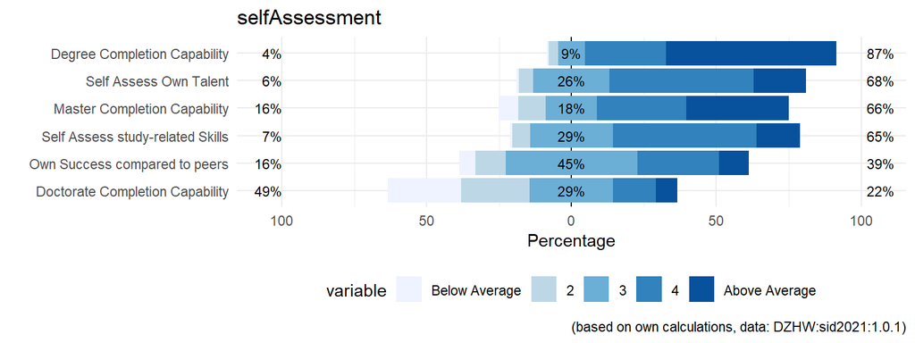

```r
data_copy <- data

df_likertSA <- data.frame(
  "sperleisrel" = data_copy$sperleisrel,
  "studerfolg" = data_copy$studerfolg,
  "masterfolg_p" = data_copy$masterfolg_p,
  "promoerfolg" = data_copy$promoerfolg,
  "sask1" = data_copy$sask1,
  "sask4" = data_copy$sask4)

df_likertSA$Q1_f <- as.factor(df_likertSA$sperleisrel)
df_likertSA$Q2_f <- as.factor(df_likertSA$studerfolg)
df_likertSA$Q3_f <- as.factor(df_likertSA$masterfolg_p)
df_likertSA$Q4_f <- as.factor(df_likertSA$promoerfolg)
df_likertSA$Q5_f <- as.factor(df_likertSA$sask1)
df_likertSA$Q7_f <- as.factor(df_likertSA$sask4)



levels <- c("Below Average", "2", "3", "4", "Above Average")

levels(df_likertSA$Q1_f) <- levels
levels(df_likertSA$Q2_f) <- levels
levels(df_likertSA$Q3_f) <- levels
levels(df_likertSA$Q4_f) <- levels
levels(df_likertSA$Q5_f) <- levels
levels(df_likertSA$Q7_f) <- levels


df_likertSA2 <- df_likertSA[, c("Q1_f", "Q2_f", "Q3_f", "Q4_f", "Q5_f", "Q7_f")]


varHeadings <- c("Own Success compared to peers",
                 "Degree Completion Capability",
                 "Master Completion Capability",
                 "Doctorate Completion Capability",
                 "Self Assess Own Talent",
                 "Self Assess study-related Skills")

names(df_likertSA2) <- varHeadings

likert_dataSA <- likert(df_likertSA2)

blues_palette <- RColorBrewer::brewer.pal(5, "Blues")


likert_plotSA <- plot(likert_dataSA) +
  ggtitle("selfAssessment") +
  labs(caption = "(based on own calculations, data: DZHW:sid2021:1.0.1)") +
  theme_minimal() +
  theme(legend.position = "bottom")

likert_plotSA <- likert_plotSA + scale_fill_manual(values = blues_palette)

likert_plotSA
```

#### 3.2.2 selfConcept

Summary

```r
alpha_resultSC <- psych::alpha(selfConc_items)

selfConc_summary <- data.frame(
  Metric = c("raw_alpha", "std.alpha", "average_r",
             "mean", "sd", "median_r"),
  Value = c(
    if("raw_alpha" %in% names(alpha_resultSC$total)) alpha_resultSC$total$raw_alpha else NA,
    if("std.alpha" %in% names(alpha_resultSC$total)) alpha_resultSC$total$std.alpha else NA,
    if("average_r" %in% names(alpha_resultSC$total)) alpha_resultSC$total$average_r else NA,
    if("mean" %in% names(alpha_resultSC$total)) alpha_resultSC$total$mean else NA,
    if("sd" %in% names(alpha_resultSC$total)) alpha_result$total$sd else NA,
    if("median_r" %in% names(alpha_resultSC$total)) alpha_resultSC$total$median_r else NA))

kable(selfConc_summary,
      format = "html",
      caption = "Index selfConcept") |>
  kable_styling(
    bootstrap_options = c("striped", "hover",
                          "condensed", "responsive"),
                full_width = F)
```

Index selfConcept

[output not shown]

Likert- Plot

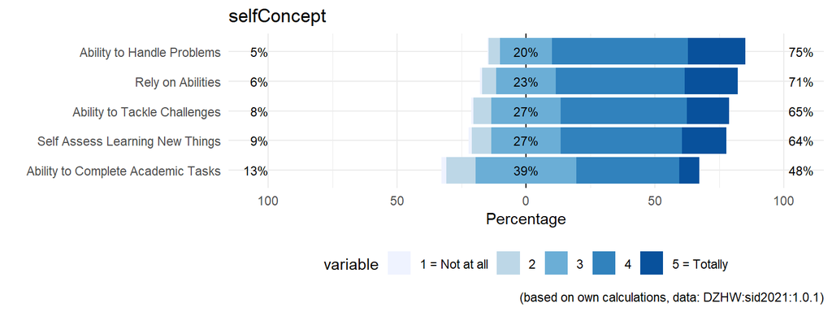

```r
attach(data_copy)

df_likertSC <- data.frame(
  "pswskill" = data_copy$pswskill,
  "pswkraft" = data_copy$pswkraft,
  "pswaufg" = data_copy$pswaufg,
  "sask2" = data_copy$sask2,
  "sask5" = data_copy$sask5)

df_likertSC$Q1_f <- as.factor(df_likertSC$pswskill)
df_likertSC$Q2_f <- as.factor(df_likertSC$pswkraft)
df_likertSC$Q3_f <- as.factor(df_likertSC$pswaufg)
df_likertSC$Q6_f <- as.factor(df_likertSC$sask2)
df_likertSC$Q8_f <- as.factor(df_likertSC$sask5)


levels <- c("1 = Not at all", "2", "3", "4", "5 = Totally")

levels(df_likertSC$Q1_f) <- levels
levels(df_likertSC$Q2_f) <- levels
levels(df_likertSC$Q3_f) <- levels
levels(df_likertSC$Q6_f) <- levels
levels(df_likertSC$Q8_f) <- levels


df_likertSC2 <- df_likertSC[, c("Q1_f", "Q2_f", "Q3_f", "Q6_f", "Q8_f")]


varHeadingsSC <- c("Rely on Abilities",
                   "Ability to Handle Problems",
                   "Ability to Tackle Challenges",
                   "Self Assess Learning New Things",
                   "Ability to Complete Academic Tasks")
names(df_likertSC2) <- varHeadingsSC

likert_dataSC <- likert(df_likertSC2)

likert_plotSC <- plot(likert_dataSC) +
  ggtitle("selfConcept") +
  labs(caption = "(based on own calculations, data: DZHW:sid2021:1.0.1)") +
  scale_fill_manual(values = blues_palette) +
  theme_minimal() +
  theme(legend.position = "bottom")

likert_plotSC <- likert_plotSC +
  scale_fill_manual(values = blues_palette)

likert_plotSC
```

#### 3.2.3 Support

Summary

```r
alpha_resultSu <- psych::alpha(supp_allItems)

supp_summary <- data.frame(
  Metric = c("raw_alpha", "std.alpha", "average_r",
             "mean", "sd", "median_r"),
  Value = c(
    if("raw_alpha" %in% names(alpha_resultSu$total)) alpha_resultSu$total$raw_alpha else NA,
    if("std.alpha" %in% names(alpha_resultSu$total)) alpha_resultSu$total$std.alpha else NA,
    if("average_r" %in% names(alpha_resultSu$total)) alpha_resultSu$total$average_r else NA,
    if("mean" %in% names(alpha_resultSu$total)) alpha_resultSu$total$mean else NA,
    if("sd" %in% names(alpha_resultSu$total)) alpha_resultSu$total$sd else NA,
    if("median_r" %in% names(alpha_resultSu$total)) alpha_resultSu$total$median_r else NA))

kable(supp_summary,
      format = "html",
      caption = "Index Support") |>
  kable_styling(
    bootstrap_options = c("striped", "hover",
                          "condensed", "responsive"),
                full_width = F)
```

Index Support

[output not shown]

Likert-Plot

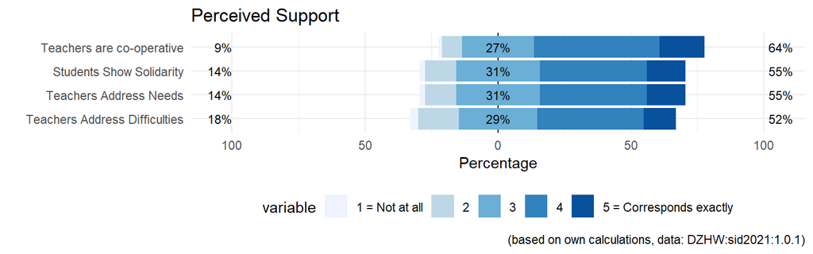

```r
# selectVars(supp_list)


df_likertSU <- data.frame(
  "sscokli1" = data_copy$sscokli1,
  "sscokli3" = data_copy$sscokli3,
  "sscokli5" = data_copy$sscokli5,
  "sscokli6" = data_copy$sscokli6
)

df_likertSU$Q1_f <- as.factor(df_likertSU$sscokli1)
df_likertSU$Q3_f <- as.factor(df_likertSU$sscokli3)
df_likertSU$Q5_f <- as.factor(df_likertSU$sscokli5)
df_likertSU$Q6_f <- as.factor(df_likertSU$sscokli6)


levels <- c("1 = Not at all",
                   "2", "3", "4",
                   "5 = Corresponds exactly")
levels(df_likertSU$Q1_f) <- levels
levels(df_likertSU$Q3_f) <- levels
levels(df_likertSU$Q5_f) <- levels
levels(df_likertSU$Q6_f) <- levels


df_likertSU2 <- df_likertSU[, c("Q1_f", "Q3_f", "Q5_f", "Q6_f")]

varHeadingsSU <- c("Teachers Address Difficulties", "Teachers are co-operative", "Teachers Address Needs", "Students Show Solidarity")
names(df_likertSU2) <- varHeadingsSU


likert_dataSU <- likert(df_likertSU2)
#plot(likert_dataSU) + ggtitle("Perceived Support Responses")

likert_plotSU <- plot(likert_dataSU) +
  ggtitle("Perceived Support") +
  labs(caption = "(based on own calculations, data: DZHW:sid2021:1.0.1)") +
  scale_fill_manual(values = blues_palette) +
  theme_minimal() +
  theme(legend.position = "bottom")
likert_plotSU <- likert_plotSU +
  scale_fill_manual(values = blues_palette)

likert_plotSU
```

### 3.3 Confounders

#### Dummy Age

```r
age_table <- table(data$age)
age_prop <- prop.table(age_table) * 100
age_cum_prop <- cumsum(age_prop)

age_freq <- data.frame(
  Value = as.numeric(names(age_table)),
  Label = c("22 years and younger", "23 years and older"),
  N = as.vector(age_table),
  Raw_Percent = round(as.numeric(intention_prop), 2),
  Valid_Percent = round(as.numeric(age_prop), 2),
  Cumulative_Percent = round(as.numeric(age_cum_prop), 2))

kableExtra::kable(age_freq, format = "html",
      col.names = c("Value", "Label", "N", "Raw %", "Valid %", "Cum. %"),
      caption = "Dummy Age")  |>
  kable_styling(bootstrap_options = c(
    "striped", "hover", "condensed", "responsive"),
                full_width = F)  |>
  #column_spec(1, bold = TRUE) |>
  #column_spec(3:6, color = "blue") |>
  add_header_above(c(" ", "Frequencies Dummy Age" = 5))
```

Dummy Age

[output not shown]

#### Dummy Parents’ Education

```r
# frq(data$parentsEducation, show.na = FALSE)

parentEduc_table <- table(data$parentsEducation)
parentEduc_prop <- prop.table(parentEduc_table) * 100
parentEduc_cum_prop <- cumsum(parentEduc_prop)

parentEduc_freq <- data.frame(
  Value = as.numeric(names(parentEduc_table)),
  Label = c("non academic", "academic"),
  N = as.vector(parentEduc_table),
  Raw_Percent = round(as.numeric(parentEduc_prop), 2),
  Valid_Percent = round(as.numeric(parentEduc_prop), 2),
  Cumulative_Percent = round(as.numeric(parentEduc_cum_prop), 2))

kableExtra::kable(parentEduc_freq, format = "html",
      col.names = c("Value", "Label", "N", "Raw %", "Valid %", "Cum. %"),
      caption = "Dummy Parents' Education")  |>
  kable_styling(bootstrap_options = c(
    "striped", "hover", "condensed", "responsive"),
                full_width = F)  |>
  #column_spec(1, bold = TRUE)  |>
 # column_spec(3:6, color = "blue") |>
  add_header_above(c(" ",
      "Frequencies Parents' Education" = 5))
```

Dummy Parents’ Education

| Value | Frequencies Parents’ Education Label | Frequencies Parents’ Education N | Frequencies Parents’ Education Raw % | Frequencies Parents’ Education Valid % | Frequencies Parents’ Education Cum. % |
| --- | --- | --- | --- | --- | --- |
| 0 | non academic | 9663 | 46.25 | 46.25 | 46.25 |
| 1 | academic | 11228 | 53.75 | 53.75 | 100.00 |

#### Dummy Subject of Study

```r
#frq(data$study_dummy, show.na = FALSE)

study_dummy_table <- table(data$studySubject)
study_dummy_prop <- prop.table(study_dummy_table) * 100
study_dummy_cum_prop <- cumsum(study_dummy_prop)

study_dummy_freq <- data.frame(
  Value = as.numeric(names(study_dummy_table)),
  Label = c("non technical/natural sciences",
            "technical/natural sciences"),
  N = as.vector(study_dummy_table),
  Raw_Percent = round(as.numeric(study_dummy_prop), 2),
  Valid_Percent = round(as.numeric(study_dummy_prop), 2),
  Cumulative_Percent = round(as.numeric(study_dummy_cum_prop), 2))

kableExtra::kable(study_dummy_freq, format = "html",
      col.names = c(
        "Value", "Label", "N", "Raw %", "Valid %", "Cum. %"),
      caption = "Dummy Subject of Study")  |>
  kable_styling(bootstrap_options = c(
    "striped", "hover", "condensed", "responsive"),
                full_width = F)  |>
  #column_spec(1, bold = TRUE)  |>
  #column_spec(3:6, color = "blue")  |>
  add_header_above(c(" ", "Frequencies Dummy Study" = 5))
```

Dummy Subject of Study

| Value | Frequencies Dummy Study Label | Frequencies Dummy Study N | Frequencies Dummy Study Raw % | Frequencies Dummy Study Valid % | Frequencies Dummy Study Cum. % |
| --- | --- | --- | --- | --- | --- |
| 0 | non technical/natural sciences | 12198 | 58.39 | 58.39 | 58.39 |
| 1 | technical/natural sciences | 8693 | 41.61 | 41.61 | 100.00 |

## 4 Test Procedures

### 4.1 t- Tests, Confidence Intervals

```r
# mean differences

t_test_selfAss <- t.test(
  selfAssessment ~ intention, data = data)

t_test_selfConc <- t.test(
  selfConcept ~ intention, data = data)

t_test_supp <- t.test(
  support ~ intention, data = data)

t_test_selfAss
```

```
##
##  Welch Two Sample t-test
##
## data:  selfAssessment by intention
## t = -70.829, df = 9311.2, p-value < 2.2e-16
## alternative hypothesis: true difference in means between group 0 and group 1 is not equal to 0
## 95 percent confidence interval:
##  -0.7717479 -0.7301813
## sample estimates:
## mean in group 0 mean in group 1
##        3.055188        3.806152
```

```r
t_test_selfConc
```

```
##
##  Welch Two Sample t-test
##
## data:  selfConcept by intention
## t = -33.547, df = 10132, p-value < 2.2e-16
## alternative hypothesis: true difference in means between group 0 and group 1 is not equal to 0
## 95 percent confidence interval:
##  -0.3470392 -0.3087221
## sample estimates:
## mean in group 0 mean in group 1
##        3.488576        3.816457
```

```r
t_test_supp
```

```
##
##  Welch Two Sample t-test
##
## data:  support by intention
## t = -12.511, df = 10667, p-value < 2.2e-16
## alternative hypothesis: true difference in means between group 0 and group 1 is not equal to 0
## 95 percent confidence interval:
##  -0.1881067 -0.1371464
## sample estimates:
## mean in group 0 mean in group 1
##        3.437417        3.600044
```

### 4.2 Errors Type I / II, Test Power

*selfAssessment*

```r
alpha <- 0.05

mean_group_0 <- mean(
  data$selfAssessment[data$intention == 0], na.rm = TRUE)
mean_group_1 <- mean(
  data$selfAssessment[data$intention == 1], na.rm = TRUE)

sd_group_0 <- sd(
  data$selfAssessment[data$intention == 0], na.rm = TRUE)
sd_group_1 <- sd(
  data$selfAssessment[data$intention == 1], na.rm = TRUE)


pooled_sd <- sqrt(((sd_group_0^2 + sd_group_1^2) / 2))

# Cohen's d
d <- (mean_group_1 - mean_group_0) / pooled_sd

n_group_0 <- sum(data$intention == 0)
n_group_1 <- sum(data$intention == 1)

#  Calculation of Test Power
pwr_result_SA <- pwr.t.test(
  d = d,
  n = min(n_group_0, n_group_1),
  sig.level = 0.05,
  type = "two.sample",
  alternative = "two.sided")

pwr_result_SA
```

```
##
##      Two-sample t test power calculation
##
##               n = 6040
##               d = 1.130579
##       sig.level = 0.05
##           power = 1
##     alternative = two.sided
##
## NOTE: n is number in *each* group
```

*selfConcept*

```r
alpha <- 0.05

mean_group_0 <- mean(
  data$selfConcept[data$intention == 0], na.rm = TRUE)
mean_group_1 <- mean(
  data$selfConcept[data$intention == 1], na.rm = TRUE)

sd_group_0 <- sd(
  data$selfConcept[data$intention == 0], na.rm = TRUE)
sd_group_1 <- sd(
  data$selfConcept[data$intention == 1], na.rm = TRUE)


pooled_sd <- sqrt(((sd_group_0^2 + sd_group_1^2) / 2))

# Cohen's d
d <- (mean_group_1 - mean_group_0) / pooled_sd

n_group_0 <- sum(data$intention == 0)
n_group_1 <- sum(data$intention == 1)

# Calculation of Test Power
pwr_result_SC <- pwr.t.test(
  d = d,
  n = min(n_group_0, n_group_1),
  sig.level = 0.05,
  type = "two.sample",
  alternative = "two.sided")

pwr_result_SC
```

```
##
##      Two-sample t test power calculation
##
##               n = 6040
##               d = 0.5242997
##       sig.level = 0.05
##           power = 1
##     alternative = two.sided
##
## NOTE: n is number in *each* group
```

*Support*

```r
alpha <- 0.05

mean_group_0 <- mean(
  data$support[data$intention == 0], na.rm = TRUE)
mean_group_1 <- mean(
  data$support[data$intention == 1], na.rm = TRUE)

sd_group_0 <- sd(
  data$support[data$intention == 0], na.rm = TRUE)
sd_group_1 <- sd(
  data$support[data$intention == 1], na.rm = TRUE)


pooled_sd <- sqrt(((sd_group_0^2 + sd_group_1^2) / 2))

# Cohen's d
d <- (mean_group_1 - mean_group_0) / pooled_sd

n_group_0 <- sum(data$intention == 0)
n_group_1 <- sum(data$intention == 1)

# Calculation of Test Power
pwr_result_SU <- pwr.t.test(
  d = d,
  n = min(n_group_0, n_group_1),
  sig.level = 0.05,
  type = "two.sample",
  alternative = "two.sided")


pwr_result_SU
```

```
##
##      Two-sample t test power calculation
##
##               n = 6040
##               d = 0.1931203
##       sig.level = 0.05
##           power = 1
##     alternative = two.sided
##
## NOTE: n is number in *each* group
```

### 4.3 Chi² Analysis

#### 4.3.1 Chi² outcome / predictors

```r
chi_intSA <- chisq.test(
                table(data$intention, data$selfAssessment))

chi_intSC <- chisq.test(
                table(data$intention, data$selfConcept))

chi_intSU <- chisq.test(
                table(data$intention, data$support))


chi_results0 <- data.frame(
  Variable = c("selfAssessment", "selfConcept", "support"),
  X_squared = c(chi_intSA$statistic,
                chi_intSC$statistic,
                chi_intSU$statistic),
  df = c(chi_intSA$parameter,
         chi_intSC$parameter,
         chi_intSU$parameter),
  p_value = c(chi_intSA$p.value,
              chi_intSC$p.value,
              chi_intSU$p.value))

chi_results0$p_value <- format.pval(chi_results0$p_value, digits = 5)


kableExtra::kable(chi_results0, format = "html",
      caption = "Chi² Test: Outcome and Predictors") |>
      kable_styling(bootstrap_options = c("striped",
      "hover", "condensed", "responsive"), full_width = F)
```

Chi² Test: Outcome and Predictors

| Variable | X_squared | df | p_value |
| --- | --- | --- | --- |
| selfAssessment | 5234.8941 | 24 | < 2.22e-16 |
| selfConcept | 1246.1474 | 20 | < 2.22e-16 |
| support | 183.9189 | 16 | < 2.22e-16 |

#### 4.3.2 Chi² outcome / confounder

age

```r
#### intention / age

# contingency
# CrossTable(data$intention, data$age)

# Chi-squared test
chi_intAge <- chisq.test(
  table(data$intention, data$age))


#chi_intAge
```

gender

```r
#### intention / gender

# contingency table
#CrossTable(data$intention, data$gender)
#table(data$intention, data$gender)

# Chi-Square-Test
chi_intGen <- chisq.test(
  table(data$intention, data$gender))
#chi_intGen
```

parents’ education

```r
#### intention / parents' education

# contingency table
#CrossTable(data$intention, data$akad_sid)

# Chi-squared- test
chi_parentEduc <- chisq.test(
  table(data$intention, data$parentsEducation))
#chi_squared_intAkad
```

subject of study

```r
#### intention / subject of study

# contingency
#CrossTable(data$intention, data$study)

# Chi squared test
chi_intStudy <- chisq.test(
  table(data$intention, data$studySubject))
#chi_intStudy
```

summary

```r
chi_results <- data.frame(
  Variable = c("age", "gender", "parentsEducation", "study"),
  X_squared = c(chi_intAge$statistic,
                chi_intGen$statistic,
                chi_parentEduc$statistic,
                chi_intStudy$statistic),
  df = c(chi_intAge$parameter,
         chi_intGen$parameter,
         chi_parentEduc$parameter,
         chi_intStudy$parameter),
  p_value = c(chi_intAge$p.value,
              chi_intGen$p.value,
              chi_parentEduc$p.value,
              chi_intStudy$p.value))

chi_results$p_value <- format.pval(chi_results$p_value, digits = 3)


kableExtra::kable(chi_results, format = "html",
      caption = "Chi² Test: Outcome and Confounder") |>
      kable_styling(bootstrap_options = c("striped", "hover",
              "condensed", "responsive"), full_width = F)
```

Chi² Test: Outcome and Confounder

| Variable | X_squared | df | p_value |
| --- | --- | --- | --- |
| age | 1274.9735816 | 1 | < 2e-16 |
| gender | 0.0094891 | 1 | 0.922 |
| parentsEducation | 509.8856977 | 1 | < 2e-16 |
| study | 15.9066161 | 1 | 6.65e-05 |

===> gender: no statistical significance ===> drop confounder gender

#### 4.3.3 Chi² predictors / confounder

*selfAssessment / confounder*

selfAssessment / age

```r
#CrossTable(data$selfAssessment, data$age)
chi_selfAss_age <- chisq.test(
  table(data$selfAssessment, data$age))
#chi_selfAss_age
```

selfAssessment / parentsEducation

```r
#CrossTable(data$selfAssessment, data$akad_sid)

chi_parentEduc <- chisq.test(
  table(data$selfAssessment, data$parentsEducation))
#chi_selfAss_akad
```

selfAssessment / study

```r
#CrossTable(data$selfAssessment, data$studySubject)

chi_selfAss_study <- chisq.test(
  table(data$selfAssessment, data$studySubject))
#chi_selfAss_study
```

*Summary selfAssessment / confounder*

```r
chi_results2 <- data.frame(
  Variable = c("age", "parentsEducation", "study"),
  X_squared = c(chi_selfAss_age$statistic,
                chi_parentEduc$statistic,
                chi_selfAss_study$statistic),
  df = c(chi_selfAss_age$parameter,
         chi_parentEduc$parameter,
         chi_selfAss_study$parameter),
  p_value = c(chi_selfAss_age$p.value,
              chi_parentEduc$p.value,
              chi_selfAss_study$p.value))

chi_results2$p_value <- format.pval(chi_results2$p_value, digits = 3)


kableExtra::kable(chi_results2, format = "html",
      caption = "Chi² Test: selfAssessment and Confounder") |>
      kable_styling(bootstrap_options = c("striped", "hover",
              "condensed", "responsive"), full_width = F)
```

Chi² Test: selfAssessment and Confounder

| Variable | X_squared | df | p_value |
| --- | --- | --- | --- |
| age | 275.56851 | 24 | < 2e-16 |
| parentsEducation | 367.30746 | 24 | < 2e-16 |
| study | 60.27669 | 24 | 5.84e-05 |

*selfConcept / confounder*

selfConcept / age

```r
#CrossTable(data$selfConcept, data$age)

chi_selfConc_age <- chisq.test(
  table(data$selfConcept, data$age))
#chi_selfConc_age
```

selfConcept / parentsEducation

```r
#CrossTable(data$selfConcept, data$akad_sid)

chi_selfConc_par <- chisq.test(
  table(data$selfConcept, data$parentsEducation))
#chi_selfConc_akad
```

selfConcept / study

```r
#CrossTable(data$selfConcept, data$studySubject)

chi_selfConc_study <- chisq.test(
  table(data$selfConcept, data$studySubject))
#chi_selfConc_study
```

*Summary selfConcept / confounder*

```r
chi_results3 <- data.frame(
  Variable = c("age", "parentsEducation", "study"),
  X_squared = c(chi_selfConc_age$statistic,
                chi_selfConc_par$statistic,
                chi_selfConc_study$statistic),
  df = c(chi_selfConc_age$parameter,
         chi_selfConc_par$parameter,
         chi_selfConc_study$parameter),
  p_value = c(chi_selfConc_age$p.value,
              chi_selfConc_par$p.value,
              chi_selfConc_study$p.value))

chi_results3$p_value <- format.pval(chi_results3$p_value, digits = 3)


kableExtra::kable(chi_results3, format = "html",
      caption = "Chi² Test: selfConcept and Confounder") |>
      kable_styling(bootstrap_options = c("striped", "hover",
              "condensed", "responsive"), full_width = F)
```

Chi² Test: selfConcept and Confounder

| Variable | X_squared | df | p_value |
| --- | --- | --- | --- |
| age | 34.73856 | 20 | 0.0215 |
| parentsEducation | 88.07182 | 20 | 1.61e-10 |
| study | 201.55096 | 20 | < 2e-16 |

*support / Confounder*

support / age

```r
#CrossTable(data$support, data$age)

chi_supp_age <- chisq.test(
  table(data$support, data$age))
#chi_supp_age
```

support / parentsEducation

```r
#CrossTable(data$support, data$parentsEducation)

chi_supp_par <- chisq.test(
  table(data$support, data$parentsEducation))
#chi_supp_akad
```

support / study

```r
#CrossTable(data$support, data$study)

chi_supp_study <- chisq.test(
  table(data$support, data$studySubject))
#chi_supp_study
```

*Summary support / Confounder*

```r
chi_results4 <- data.frame(
  Variable = c("age", "parentsEducation", "study"),
  X_squared = c(chi_supp_age$statistic,
                chi_supp_par$statistic,
                chi_supp_study$statistic),
  df = c(chi_supp_age$parameter,
         chi_supp_par$parameter,
         chi_supp_study$parameter),
  p_value = c(chi_supp_age$p.value,
              chi_supp_par$p.value,
              chi_supp_study$p.value))

chi_results4$p_value <- format.pval(chi_results4$p_value, digits = 3)


kableExtra::kable(chi_results4, format = "html",
      caption = "Chi² Test: Perceived Support and Confounder") |>
      kable_styling(bootstrap_options = c("striped", "hover",
              "condensed", "responsive"), full_width = F)
```

Chi² Test: Perceived Support and Confounder

| Variable | X_squared | df | p_value |
| --- | --- | --- | --- |
| age | 68.23657 | 16 | 2.03e-08 |
| parentsEducation | 34.62826 | 16 | 0.004467 |
| study | 43.13430 | 16 | 0.000267 |

#### 4.3.4 Chi² between predictors

```r
chi_pred1 <- chisq.test(table(data$selfAssessment,
                              data$selfConcept))

chi_pred2 <- chisq.test(table(data$selfAssessment,
                              data$support))

chi_pred3 <- chisq.test(table(data$selfConcept,
                              data$support))


chi_pred <- data.frame(
  Variable = c("selfAssessment", "selfConcept", "support"),
  X_squared = c(chi_pred1$statistic,
                chi_pred2$statistic,
                chi_pred3$statistic),
  df = c(chi_pred1$parameter,
         chi_pred2$parameter,
         chi_pred3$parameter),
  p_value = c(chi_pred1$p.value,
              chi_pred2$p.value,
              chi_pred3$p.value))

chi_pred$p_value <- format.pval(chi_pred$p_value, digits = 3)


kableExtra::kable(chi_pred, format = "html",
      caption = "Chi² Test: Predictors") |>
      kable_styling(bootstrap_options = c("striped", "hover",
              "condensed", "responsive"), full_width = F)
```

Chi² Test: Predictors

| Variable | X_squared | df | p_value |
| --- | --- | --- | --- |
| selfAssessment | 19378.594 | 480 | <2e-16 |
| selfConcept | 1650.276 | 384 | <2e-16 |
| support | 1830.058 | 320 | <2e-16 |

The very high Chi² values and extremely low p-values indicate that the null hypothesis (that the variables are independent of each other) is rejected in all cases.

There are significant associations between the variables under investigation (selfAssessment, selfConcept, and support).

Furthermore, the results suggest a potential issue with *heteroscedasticity*, as indicated by the variability in the effect sizes and large Chi² values.

Additionally, these findings may indicate the presence of *multicollinearity*, as strong associations between predictors can complicate the interpretation of their individual effects in a model.

=> The VIF test and Breusch-Pagan test for further investigation

### 4.4 VIF- Test

The Variance Inflation Factor (VIF) test is used to check for *multicollinearity* in regression models. Multicollinearity occurs when predictor variables are highly correlated, which can affect the stability and interpretation of the regression coefficients.

```r
plain_model <- glm(
  intention ~ selfAssessment + selfConcept + support,
  data = data, family = binomial)


perform_chisq_tests <- function(data, predictors) {
  results <- list()
  for (i in 1:(length(predictors) - 1)) {
    for (j in (i + 1):length(predictors)) {
      table <- table(data[[predictors[i]]], data[[predictors[j]]])
      test_result <- chisq.test(table)
      results[[paste(predictors[i], "vs",
                     predictors[j])]] <- test_result
    }
  }
  return(results)
}


predictors <- c("selfAssessment","selfConcept", "support")
chi_results <- perform_chisq_tests(data, predictors)

model <- plain_model
vif(model)
```

```
## selfAssessment    selfConcept        support
##       1.700102       1.686481       1.054243
```

Interpretation:

VIF < 1: No correlation among predictor variables. 1 ≤ VIF < 5: Low to moderate correlation that is generally acceptable. VIF ≥ 5: High correlation, potential multicollinearity issue. VIF ≥ 10: Very high correlation, serious multicollinearity issue.

Given that all VIF values are below 5, this indicates that there is *no significant multicollinearity* among the predictor variables. Overall, the VIF test results suggest that multicollinearity is not a concern in your model, and the predictor variables are not highly correlated with each other. This means the regression coefficients should be stable and interpretable.

### 4.5 Breusch-Pagan-Test

The Studentized Breusch-Pagan test is used to detect *heteroscedasticity* in a regression model. Heteroscedasticity occurs when the variance of the residuals (errors) is not constant across all levels of the independent variables. This can affect the validity of statistical tests and confidence intervals.

```r
lmtest::bptest(model)
```

```
##
##  studentized Breusch-Pagan test
##
## data:  model
## BP = 770.35, df = 3, p-value < 2.2e-16
```

Since the p-value is extremely small, we reject the null hypothesis of homoscedasticity. This means there is *significant evidence of heteroscedasticity* in the model. In other words, the variance of the residuals is not constant, and this violation needs to be addressed to ensure the reliability of the regression results.

Potential remedies for heteroscedasticity: - transforming the dependent variable, or - adding relevant predictors, or - using robust standard errors. It is important to address heteroscedasticity to improve the accuracy and validity of the regression analysis.

=> The variance of the error terms is not constant and changes with the value of one or more independent variables.

=> Adding predictors is not the goal, so consider transforming the outcome or using robust standard errors (see Chapter 5: Options for Modeling).

### 4.6 Visual Inspection

#### 4.6.1 Direct Predictors’ Effects

*selfAssessment*

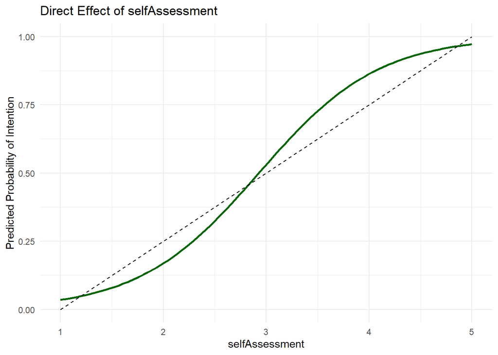

```r
effect_SA <- glm(intention ~ selfAssessment,
                 data = data, family = binomial)
df_sa <- data.frame(
  selfAssessment = seq(min(data$selfAssessment),
                       max(data$selfAssessment),
                       length.out = 100))

df_sa$predicted <- predict(effect_SA,
                           newdata = df_sa,
                           type = "response")

ggplot(df_sa,
       aes(x = selfAssessment, y = predicted)) +
    geom_line(color = "darkgreen", size = 1) +
  geom_segment(aes(x = 1, y = 0, xend = 5, yend = 1),
               linetype = "dashed", color = "black") +
  labs(title = "Direct Effect of selfAssessment",
       x = "selfAssessment",
       y = "Predicted Probability of Intention") +
  theme_minimal()
```

=> critical Non-linear Effect

*selfConcept*

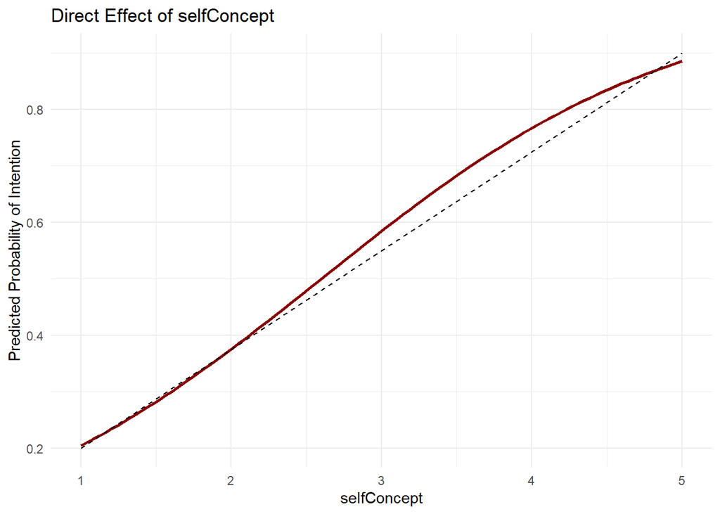

```r
effect_sc <- glm(intention ~ selfConcept,
                 data = data, family = binomial)

df_sc <- data.frame(
  selfConcept = seq(min(data$selfConcept),
                    max(data$selfConcept),
                    length.out = 100))

df_sc$predicted <- predict(effect_sc,
                           newdata = df_sc,
                           type = "response")

ggplot(df_sc,
       aes(x = selfConcept, y = predicted)) +
  geom_line(color = "darkred", size = 1) +
  geom_segment(aes(x = 1, y = 0.2, xend = 5, yend = 0.9),
               linetype = "dashed", color = "black") +
  labs(title = "Direct Effect of selfConcept",
       x = "selfConcept",
       y = "Predicted Probability of Intention") +
  theme_minimal()
```

=> non-linear Effect, not critical

*support*

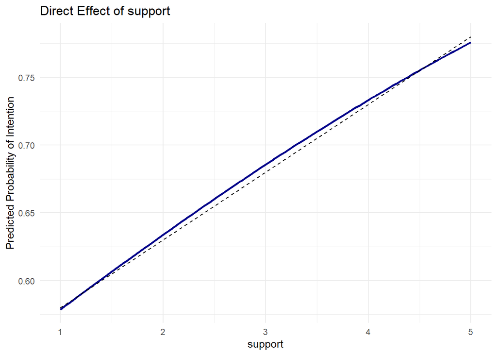

```r
effect_su <- glm(intention ~ support,
                 data = data,
                 family = binomial)

df_su <- data.frame(support = seq(min(data$support),
                                  max(data$support),
                                  length.out = 100))

df_su$predicted <- predict(effect_su,
                           newdata = df_su,
                           type = "response")

ggplot(df_su,
       aes(x = support, y = predicted)) +
  geom_line(color = "darkblue", size = 1) +
  geom_segment(aes(x = 1, y = 0.58,
               xend = 5, yend = 0.78),
               linetype = "dashed",
               color = "black") +
  labs(title = "Direct Effect of support",
       x = "support",
       y = "Predicted Probability of Intention") +
  theme_minimal()
```

=> non critical Effect

#### 4.6.2 Residuals Plots

*selfAssessment*

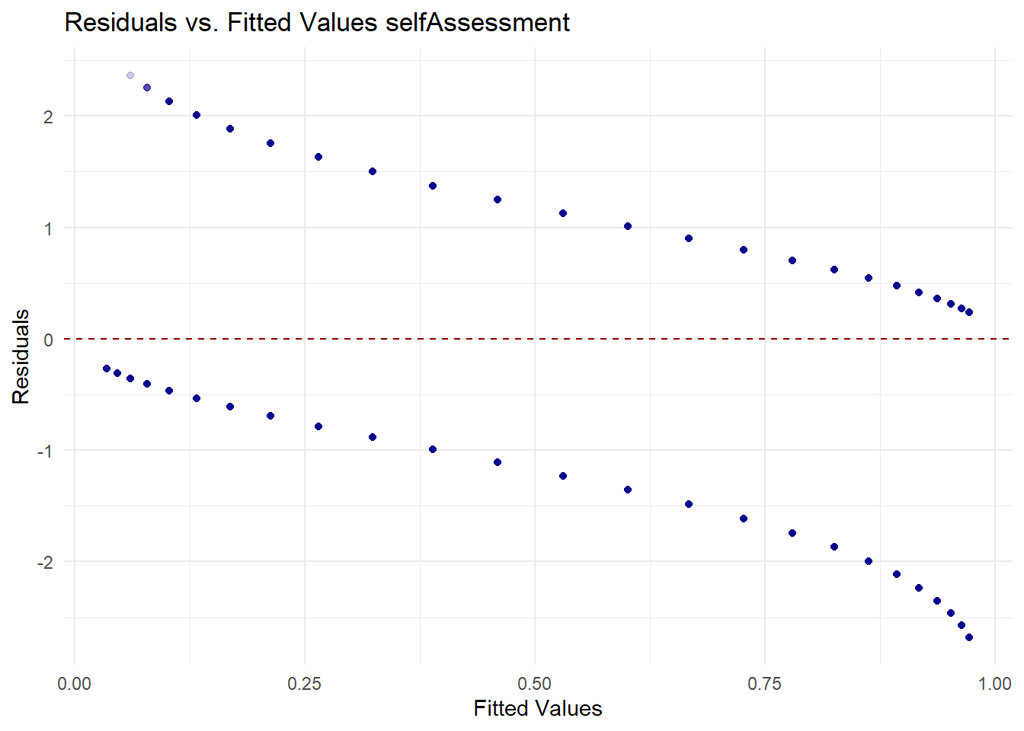

```r
effect_SA <- glm(intention ~ selfAssessment,
                 data = data, family = binomial)

ggplot(data = data,
       aes(x = fitted(effect_SA),
           y = resid(effect_SA))) +
  geom_point(color = "darkblue", alpha = 0.2) +
  geom_hline(yintercept = 0, linetype = "dashed", color = "darkred") +
  labs(x = "Fitted Values", y = "Residuals") +
  ggtitle("Residuals vs. Fitted Values selfAssessment") +
  theme_minimal()
```

*selfConcept*

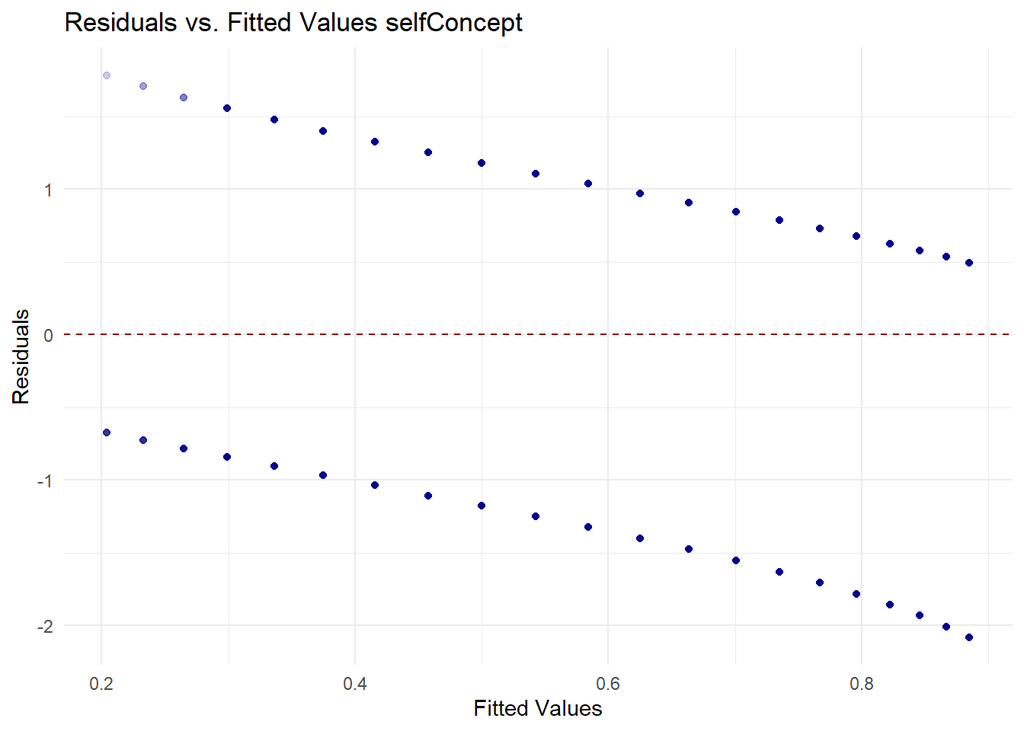

```r
effect_sc <- glm(intention ~ selfConcept,
                 data = data, family = binomial)

ggplot(data = data,
       aes(x = fitted(effect_sc),
           y = resid(effect_sc))) +
  geom_point(color = "darkblue", alpha = 0.2) +
  geom_hline(yintercept = 0, linetype = "dashed", color = "darkred") +
  labs(x = "Fitted Values", y = "Residuals") +
  ggtitle("Residuals vs. Fitted Values selfConcept") +
  theme_minimal()
```

*support*

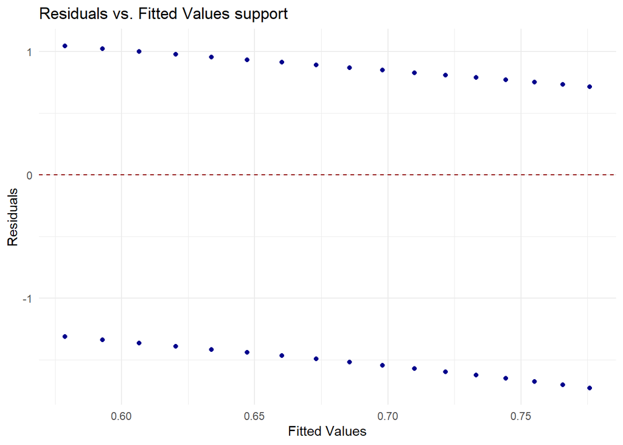

```r
effect_su <- glm(intention ~ support,
                 data = data,
                 family = binomial)

ggplot(data = data,
       aes(x = fitted(effect_su),
           y = resid(effect_su))) +
  geom_point(color = "darkblue", alpha = 0.2) +
  geom_hline(yintercept = 0, linetype = "dashed", color = "darkred") +
  labs(x = "Fitted Values", y = "Residuals") +
  ggtitle("Residuals vs. Fitted Values support") +
  theme_minimal()
```

## 5 Options for Modeling

Options A and B address the issue of *heteroskedasticity*, while C, D, and E are methods to compensate for the *nonlinear effect*.

Since solutions for both issues must be found, the best combination of these methods should be determined.

### 5.1 Handling Heteroskedasticity

#### 5.1.1 Option A

*Log-transformation of the outcome variable*

involves taking the natural logarithm of the values, which helps stabilize variance across different value ranges and thus mitigates the problem of heteroskedasticity. This transformation makes the distribution more symmetric and reduces variance in the data, leading to more reliable and robust model estimations.

```r
data$log_intention <- log(data$intention + 1)
option_A <- glm(log_intention ~ selfAssessment +
                   selfConcept + support +
                   age + parentsEducation + studySubject,
                 data = data, family = gaussian)

summary(option_A)
```

```
##
## Call:
## glm(formula = log_intention ~ selfAssessment + selfConcept +
##     support + age + parentsEducation + studySubject, family = gaussian,
##     data = data)
##
## Coefficients:
##                   Estimate Std. Error t value Pr(>|t|)
## (Intercept)      -0.084433   0.013184  -6.404 1.54e-10 ***
## selfAssessment    0.228201   0.003480  65.574  < 2e-16 ***
## selfConcept      -0.054008   0.003949 -13.678  < 2e-16 ***
## support          -0.005117   0.002277  -2.248   0.0246 *
## age              -0.118267   0.003781 -31.280  < 2e-16 ***
## parentsEducation  0.043295   0.003773  11.475  < 2e-16 ***
## studySubject      0.015911   0.003770   4.221 2.44e-05 ***
## ---
## Signif. codes:  0 '***' 0.001 '**' 0.01 '*' 0.05 '.' 0.1 ' ' 1
##
## (Dispersion parameter for gaussian family taken to be 0.07130581)
##
##     Null deviance: 2062.9  on 20890  degrees of freedom
## Residual deviance: 1489.2  on 20884  degrees of freedom
## AIC: 4126.6
##
## Number of Fisher Scoring iterations: 2
```

#### 5.1.2 Option B

*Robust Standard Errors*

are used to account for heteroscedasticity in a regression model. When heteroscedasticity is present, the usual standard errors may be biased. Robust standard errors correct for this, providing more reliable estimates of the coefficients’ standard errors.

HC1: Heteroskedasticity-Consistent Standard Errors, Version 1

```r
option_B <- glm(intention ~ selfAssessment +
    selfConcept + support,
    data = data, family = binomial)

robust_se <- lmtest::coeftest(option_B,
            vcov = sandwich::vcovHC(model, type = "HC1"))

texreg::screenreg(list(option_B),
          override.se = list(robust_se))
```

```
##
## ============================
##                 Model 1
## ----------------------------
## (Intercept)        -4.04 ***
##                    (0.12)
## selfAssessment      2.05 ***
##                    (0.04)
## selfConcept        -0.55 ***
##                    (0.04)
## support            -0.04
##                    (0.02)
## ----------------------------
## AIC             19926.85
## BIC             19958.64
## Log Likelihood  -9959.42
## Deviance        19918.85
## Num. obs.       20891
## ============================
## *** p < 0.001; ** p < 0.01; * p < 0.05
```

#### 5.1.3 Comparison

```r
hoslem1 <- hoslem.test(
           data$log_intention, fitted(option_A))
hoslem2 <- hoslem.test(data$intention, fitted(option_B))

aic1 <- AIC(option_A)
aic2 <- AIC(option_B)

logLik1 <- logLik(option_A)
logLik2 <- logLik(option_B)


results <- data.frame(
  Option = c("A", "B"),
  Model = c("log Transformation",
            "Robust Standard Errors"),
  `Hoslem X²` = c(hoslem1$statistic, hoslem2$statistic),
  `Hoslem p-value` = c(format.pval(hoslem1$p.value),
                       format.pval(hoslem2$p.value)),
  AIC = c(aic1, aic2),
  `Log-Likelihood` = c(logLik1, logLik2))

results  |>
  kable("html", escape = FALSE,
  align = "r",
  caption = "Comparison of Model Performance")  |>
  kable_styling(full_width = T,
  bootstrap_options = c("striped", "hover", "condensed", "responsive"))
```

Comparison of Model Performance

| Option | Model | Hoslem.X. | Hoslem.p.value | AIC | Log.Likelihood |
| --- | --- | --- | --- | --- | --- |
| A | log Transformation | 233.3490 | < 2.22e-16 | 4126.607 | -2055.303 |
| B | Robust Standard Errors | 166.3941 | < 2.22e-16 | 19926.847 | -9959.424 |

### 5.2 Handling Nonlinear Effects

#### 5.2.1 Option C

*Modeling Interactions*

compensates for nonlinear effects by capturing the combined influence of two or more variables on the outcome, which can reveal complex, nonlinear relationships that a simple additive model might miss.

```r
option_C <- glm(
  intention ~ selfAssessment * selfConcept +
              selfAssessment * support +
              selfConcept * support,
              data = data, family = binomial)

summary(option_C)
```

```
##
## Call:
## glm(formula = intention ~ selfAssessment * selfConcept + selfAssessment *
##     support + selfConcept * support, family = binomial, data = data)
##
## Coefficients:
##                            Estimate Std. Error z value Pr(>|z|)
## (Intercept)                -5.62812    0.57666  -9.760  < 2e-16 ***
## selfAssessment              2.34399    0.20315  11.538  < 2e-16 ***
## selfConcept                 0.14819    0.18593   0.797 0.425455
## support                    -0.10310    0.13232  -0.779 0.435896
## selfAssessment:selfConcept -0.15575    0.04140  -3.762 0.000168 ***
## selfAssessment:support      0.08000    0.04270   1.874 0.060976 .
## selfConcept:support        -0.05555    0.04160  -1.335 0.181767
## ---
## Signif. codes:  0 '***' 0.001 '**' 0.01 '*' 0.05 '.' 0.1 ' ' 1
##
## (Dispersion parameter for binomial family taken to be 1)
##
##     Null deviance: 25126  on 20890  degrees of freedom
## Residual deviance: 19901  on 20884  degrees of freedom
## AIC: 19915
##
## Number of Fisher Scoring iterations: 4
```

#### 5.2.2 Option D

*Polynomial Transformation*

compensates for nonlinear effects by allowing the model to include higher-degree terms of predictor variables, which can capture complex, curved relationships between predictors and the outcome that linear terms alone cannot represent.

```r
option_D <- glm(
  intention ~ poly(selfAssessment, 2) +
    selfConcept + support,
    data = data, family = binomial)

summary(option_D)
```

```
##
## Call:
## glm(formula = intention ~ poly(selfAssessment, 2) + selfConcept +
##     support, family = binomial, data = data)
##
## Coefficients:
##                           Estimate Std. Error z value Pr(>|z|)
## (Intercept)                3.29169    0.15745  20.907  < 2e-16 ***
## poly(selfAssessment, 2)1 210.40394    3.89778  53.980  < 2e-16 ***
## poly(selfAssessment, 2)2 -24.46838    3.48668  -7.018 2.26e-12 ***
## selfConcept               -0.55239    0.03768 -14.660  < 2e-16 ***
## support                   -0.03956    0.02175  -1.819   0.0689 .
## ---
## Signif. codes:  0 '***' 0.001 '**' 0.01 '*' 0.05 '.' 0.1 ' ' 1
##
## (Dispersion parameter for binomial family taken to be 1)
##
##     Null deviance: 25126  on 20890  degrees of freedom
## Residual deviance: 19869  on 20886  degrees of freedom
## AIC: 19879
##
## Number of Fisher Scoring iterations: 4
```

#### 5.2.3 Option E

*Implementing Splines*

compensates for nonlinear effects by using piecewise polynomial functions to model the relationship between variables, allowing for flexibility in capturing complex, nonlinear patterns in the data.

```r
option_E <- mgcv::gam(
  intention ~ s(selfAssessment) +
    selfConcept + support,
  data = data, family = binomial)

summary(option_E)
```

```
##
## Family: binomial
## Link function: logit
##
## Formula:
## intention ~ s(selfAssessment) + selfConcept + support
##
## Parametric coefficients:
##             Estimate Std. Error z value Pr(>|z|)
## (Intercept)  3.28449    0.15776  20.819   <2e-16 ***
## selfConcept -0.54414    0.03778 -14.405   <2e-16 ***
## support     -0.04355    0.02181  -1.997   0.0458 *
## ---
## Signif. codes:  0 '***' 0.001 '**' 0.01 '*' 0.05 '.' 0.1 ' ' 1
##
## Approximate significance of smooth terms:
##                     edf Ref.df Chi.sq p-value
## s(selfAssessment) 7.981  8.509   3170  <2e-16 ***
## ---
## Signif. codes:  0 '***' 0.001 '**' 0.01 '*' 0.05 '.' 0.1 ' ' 1
##
## R-sq.(adj) =  0.261   Deviance explained = 21.3%
## UBRE = -0.052812  Scale est. = 1         n = 20891
```

#### 5.2.4 Comparison

```r
hoslem3 <- hoslem.test(data$intention, fitted(option_C))
hoslem4 <- hoslem.test(data$intention, fitted(option_D))
hoslem5 <- hoslem.test(data$intention, fitted(option_E))


aic3 <- AIC(option_C)
aic4 <- AIC(option_D)
aic5 <- AIC(option_E)


logLik3 <- logLik(option_C)
logLik4 <- logLik(option_D)
logLik5 <- logLik(option_E)


results <- data.frame(
  Option = c("C", "D", "E"),
  Model = c("Interactions",
            "Polynomial Transformation",
            "Splines"),
  `Hoslem X²` = c(
          hoslem3$statistic, hoslem4$statistic,
          hoslem5$statistic),
  `Hoslem p-value` = c(format.pval(hoslem3$p.value),
                       format.pval(hoslem4$p.value),
                       format.pval(hoslem5$p.value)),
  AIC = c(aic3, aic4, aic5),
  `Log-Likelihood` = c(logLik3, logLik4, logLik5))

results  |>
  kable("html", escape = FALSE,
  align = "r",
  caption = "Comparison of Model Performance")  |>
  kable_styling(full_width = T,
  bootstrap_options = c("striped", "hover", "condensed", "responsive"))
```

Comparison of Model Performance

| Option | Model | Hoslem.X. | Hoslem.p.value | AIC | Log.Likelihood |
| --- | --- | --- | --- | --- | --- |
| C | Interactions | 136.18713 | < 2.22e-16 | 19914.79 | -9950.394 |
| D | Polynomial Transformation | 84.83026 | 5.218e-15 | 19878.56 | -9934.282 |
| E | Splines | 18.14407 | 0.020172 | 19787.71 | -9882.872 |

### 5.3. Combinations

#### 5.3.1 Option F

combination of Option A and Option E:

Log-transformation of the outcome variable and implementing splines

```r
option_F <- mgcv::gam(
  log_intention ~ s(selfAssessment) +
    selfConcept + support,
  data = data, family = binomial)

summary(option_F)
```

```
##
## Family: binomial
## Link function: logit
##
## Formula:
## log_intention ~ s(selfAssessment) + selfConcept + support
##
## Parametric coefficients:
##             Estimate Std. Error z value Pr(>|z|)
## (Intercept)  1.01025    0.13004   7.769 7.92e-15 ***
## selfConcept -0.27275    0.03172  -8.598  < 2e-16 ***
## support     -0.01936    0.01811  -1.069    0.285
## ---
## Signif. codes:  0 '***' 0.001 '**' 0.01 '*' 0.05 '.' 0.1 ' ' 1
##
## Approximate significance of smooth terms:
##                     edf Ref.df Chi.sq p-value
## s(selfAssessment) 7.908  8.412   1495  <2e-16 ***
## ---
## Signif. codes:  0 '***' 0.001 '**' 0.01 '*' 0.05 '.' 0.1 ' ' 1
##
## R-sq.(adj) =  0.258   Deviance explained = 21.5%
## UBRE = -0.59913  Scale est. = 1         n = 20891
```

#### 5.3.2 Option G

combination of Option B and Option E:

using robust standard errors and implementing splines

```r
option_G <- mgcv::gam(
  intention ~ s(selfAssessment) +
    selfConcept + support +
    age + parentsEducation + study,
  data = data, family = binomial)

robust_se_G <- sqrt(diag(vcovHC(option_G,
                                type = "HC1")))

texreg::screenreg(list(option_G),
          override.se = list(robust_se_G))
```

```
##
## ====================================
##                         Model 1
## ------------------------------------
## (Intercept)                 3.25 ***
##                            (0.17)
## selfConcept                -0.45 ***
##                            (0.04)
## support                    -0.06 **
##                            (0.02)
## age                        -1.09 ***
##                            (0.04)
## parentsEducation            0.43 ***
##                            (0.04)
## study                       0.19 ***
##                            (0.04)
## EDF: s(selfAssessment)      7.96 ***
##                            (8.51)
## ------------------------------------
## AIC                     18630.00
## BIC                     18740.97
## Log Likelihood          -9301.03
## Deviance                18602.07
## Deviance explained          0.26
## Dispersion                  1.00
## R^2                         0.31
## GCV score                  -0.11
## Num. obs.               20891
## Num. smooth terms           1
## ====================================
## *** p < 0.001; ** p < 0.01; * p < 0.05
```

### 5.4. Comparison of Model Performance

*Hosmer-Lemeshow-Test*

Hoslem values evaluate the fit of a model to the data:

*Hoslem X²*: - Test statistic that measures the quality of fit to the data. - Rule: The lower, the better.

*Hoslem p-value*: - Good fit means no significant deviance. - Rule: The higher (greater than 0.05), the better.

AIC and Log-Likelihood assess the explanatory power of a model and how well it describes the data:

*AIC* (Akaike Information Criterion): - Measures the quality of fit of a statistical model. - Rule: The lower, the better.

*log.Likelihood*: - Measures the quality of fit of a statistical model. - Rule: The higher, the better.

```r
hoslem6 <- hoslem.test(
           data$log_intention, fitted(option_F))
hoslem7 <- hoslem.test(data$intention, fitted(option_G))

aic6 <- AIC(option_F)
aic7 <- AIC(option_G)

logLik6 <- logLik(option_F)
logLik7 <- logLik(option_G)


results <- data.frame(
  Option = c("F = A + E", "G = B + E"),
  Model = c("log-Transf. + Splines",
            "Robust SE + Splines"),
  `Hoslem X²` = c(hoslem6$statistic,
                  hoslem7$statistic),
  `Hoslem p-value` = c(format.pval(hoslem6$p.value),
                       format.pval(hoslem7$p.value)),
  AIC = c(aic6, aic7),
  `Log-Likelihood` = c(logLik6, logLik7))

results  |>
  kable("html", escape = FALSE,
  align = "r",
  caption = "Comparison of Model Performance")  |>
  kable_styling(full_width = T,
  bootstrap_options = c("striped", "hover", "condensed", "responsive"))
```

Comparison of Model Performance

| Option | Model | Hoslem.X. | Hoslem.p.value | AIC | Log.Likelihood |
| --- | --- | --- | --- | --- | --- |
| F = A + E | log-Transf. + Splines | 15.662425 | 0.047475 | 25129.63 | -12553.908 |
| G = B + E | Robust SE + Splines | 5.734416 | 0.67695 | 18630.00 | -9301.035 |

## 6 Regression GAM

### 6.1. Null Model

```r
null_model <- glm(intention ~ 1,
                 data = data,
                 family = binomial)


stargazer(null_model, type = "text",
          ci = TRUE, ci.level = 0.95,
          single.row = TRUE,
          star.cutoffs = c(0.05, 0.01, 0.001),
          header = F,
          title = "Null Model, Split 1",
          dep.var.labels = "Master- Intention")
```

```
##
## Null Model, Split 1
## ===============================================
##                        Dependent variable:
##                   -----------------------------
##                         Master- Intention
## -----------------------------------------------
## Constant             0.900*** (0.870, 0.930)
## -----------------------------------------------
## Observations                 20,891
## Log Likelihood             -12,563.050
## Akaike Inf. Crit.          25,128.090
## ===============================================
## Note:             *p<0.05; **p<0.01; ***p<0.001
```

```r
# Log-Likelihood
ll_model <- null_model
ll_null <- logLik(null_model)
ll_null
```

```
## 'log Lik.' -12563.05 (df=1)
```

### 6.2 Model with Predictors

```r
predictor_model <- mgcv::gam(
  intention ~ s(selfAssessment) +
    selfConcept + support,
  data = data,
  family = binomial
)

# calculate robust standard errors

robust_se_pM <- lmtest::coeftest(predictor_model,
                   vcov = sandwich::vcovHC(
                    predictor_model, type = "HC1"))
#robust_se_pM

# Log-Likelihood
ll_Pmodel <- logLik(predictor_model)

# McFadden-R²
mcfadden_r2 <- 1 - (as.numeric(ll_Pmodel) / as.numeric(ll_null))
mcfadden_r2
```

```
## [1] 0.2133379
```

```r
texreg::screenreg(list(predictor_model),
          override.se = list(robust_se_pM))
```

```
##
## ====================================
##                         Model 1
## ------------------------------------
## (Intercept)                 3.28 ***
##                            (0.16)
## selfConcept                -0.54 ***
##                            (0.04)
## support                    -0.04 *
##                            (0.02)
## EDF: s(selfAssessment)      7.98 ***
##                            (8.51)
## ------------------------------------
## AIC                     19787.71
## BIC                     19874.98
## Log Likelihood          -9882.87
## Deviance                19765.74
## Deviance explained          0.21
## Dispersion                  1.00
## R^2                         0.26
## GCV score                  -0.05
## Num. obs.               20891
## Num. smooth terms           1
## ====================================
## *** p < 0.001; ** p < 0.01; * p < 0.05
```

### 6.3 Full Model

```r
full_model <- mgcv::gam(
  intention ~ s(selfAssessment) +
    selfConcept + support +
    age + parentsEducation + study,
  data = data, family = binomial)

# calculate robust standard errors

robust_se_fM <- sqrt(diag(vcovHC(full_model, type = "HC1")))
#robust_se_pM

#length(robust_se_fM)
#length(coef(full_model))

# Log-Likelihood
ll_fmodel <- logLik(full_model)

# McFadden-R²
mcfadden_r2 <- 1 - (as.numeric(ll_fmodel) / as.numeric(ll_null))
#mcfadden_r2

texreg::screenreg(list(full_model),
          override.se = list(robust_se_pM))
```

```
##
## ====================================
##                         Model 1
## ------------------------------------
## (Intercept)                 3.25 ***
##                            (0.17)
## selfConcept                -0.45 ***
##                            (0.04)
## support                    -0.06 **
##                            (0.02)
## age                        -1.09 ***
##                            (0.04)
## parentsEducation            0.43 ***
##                            (0.04)
## study                       0.19 ***
##                            (0.04)
## EDF: s(selfAssessment)      7.96 ***
##                            (8.51)
## ------------------------------------
## AIC                     18630.00
## BIC                     18740.97
## Log Likelihood          -9301.03
## Deviance                18602.07
## Deviance explained          0.26
## Dispersion                  1.00
## R^2                         0.31
## GCV score                  -0.11
## Num. obs.               20891
## Num. smooth terms           1
## ====================================
## *** p < 0.001; ** p < 0.01; * p < 0.05
```

### 6.4 Comparison

```r
texreg::screenreg(list(null_model, predictor_model,
                       full_model),
          override.se = list(robust_se_pM))
```

```
##
## =================================================================
##                         Model 1        Model 2       Model 3
## -----------------------------------------------------------------
## (Intercept)                  0.90 ***      3.28 ***      3.25 ***
##                             (0.02)        (0.16)        (0.17)
## selfConcept                               -0.54 ***     -0.45 ***
##                                           (0.04)        (0.04)
## support                                   -0.04 *       -0.06 **
##                                           (0.02)        (0.02)
## EDF: s(selfAssessment)                     7.98 ***      7.96 ***
##                                           (8.51)        (8.51)
## age                                                     -1.09 ***
##                                                         (0.04)
## parentsEducation                                         0.43 ***
##                                                         (0.04)
## study                                                    0.19 ***
##                                                         (0.04)
## -----------------------------------------------------------------
## AIC                      25128.09      19787.71      18630.00
## BIC                      25136.04      19874.98      18740.97
## Log Likelihood          -12563.05      -9882.87      -9301.03
## Deviance                 25126.09      19765.74      18602.07
## Num. obs.                20891         20891         20891
## Deviance explained                         0.21          0.26
## Dispersion                                 1.00          1.00
## R^2                                        0.26          0.31
## GCV score                                 -0.05         -0.11
## Num. smooth terms                          1             1
## =================================================================
## *** p < 0.001; ** p < 0.01; * p < 0.05
```

Table

```r
loglik_AIC_BIC <- function(model) {
  data.frame(
    Log_Likelihood = as.numeric(logLik(model)),
    AIC = AIC(model),
    BIC = BIC(model),
    stringsAsFactors = FALSE
  )
}

null_loglik <- loglik_AIC_BIC(null_model)
predictor_loglik <- loglik_AIC_BIC(predictor_model)
full_loglik <- loglik_AIC_BIC(full_model)

# Likelihoods

likelihoods <- rbind(
  cbind(Model = "Null Model", null_loglik),
  cbind(Model = "Predictor Model", predictor_loglik),
  cbind(Model = "Full Model", full_loglik)
)

likelihoods_kable <- likelihoods  |>
  kableExtra::kable()  |>
  kable_styling(bootstrap_options = c(
    "striped", "hover", "condensed", "responsive"))

likelihoods_kable
```

| Model | Log_Likelihood | AIC | BIC |
| --- | --- | --- | --- |
| Null Model | -12563.045 | 25128.09 | 25136.04 |
| Predictor Model | -9882.872 | 19787.71 | 19874.98 |
| Full Model | -9301.035 | 18630.00 | 18740.97 |

### 6.5 Log Odds and Max Likelihoods

```r
my_model <- mgcv::gam(
  intention ~ s(selfAssessment) +
    selfConcept + support +
    age + parentsEducation + study,
  data = data, family = binomial)

coef_estimates <- coef(my_model)
se_estimates <- summary(my_model)$se

conf_intervals <- data.frame(
  term = names(coef_estimates),
  estimate = coef_estimates,
  std.error = se_estimates,
  CI.Lower = coef_estimates - 1.96 * se_estimates,
  CI.Upper = coef_estimates + 1.96 * se_estimates
)

# Odds Ratios
conf_intervals <- conf_intervals  |>
  mutate(OddsRatio = exp(estimate))

conf_intervals  |>
  select(term, estimate,  OddsRatio, CI.Lower, CI.Upper)  |>
  kableExtra::kable(
    format = "html",
    caption = "Coefficient Estimates,
    Odds Ratios, Confidence Intervals") |>
  kable_styling(
    bootstrap_options = c("striped", "hover", "condensed"),
    full_width = F)  |>
  row_spec(0, bold = TRUE)
```

Coefficient Estimates, Odds Ratios, Confidence Intervals

|  | term | estimate | OddsRatio | CI.Lower | CI.Upper |
| --- | --- | --- | --- | --- | --- |
| (Intercept) | (Intercept) | 3.2502341 | 25.7963780 | 2.9231986 | 3.5772696 |
| selfConcept | selfConcept | -0.4508394 | 0.6370931 | -0.5272827 | -0.3743961 |
| support | support | -0.0614446 | 0.9404051 | -0.1054273 | -0.0174619 |
| age | age | -1.0913642 | 0.3357581 | -1.1646496 | -1.0180789 |
| parentsEducation | parentsEducation | 0.4347767 | 1.5446182 | 0.3624110 | 0.5071424 |
| study | study | 0.1949277 | 1.2152231 | 0.1208713 | 0.2689840 |
| s(selfAssessment).1 | s(selfAssessment).1 | -1.1203623 | 0.3261616 | -2.2346291 | -0.0060956 |
| s(selfAssessment).2 | s(selfAssessment).2 | 3.5196703 | 33.7732930 | 0.5524406 | 6.4869001 |
| s(selfAssessment).3 | s(selfAssessment).3 | 0.7138623 | 2.0418622 | -0.0121972 | 1.4399217 |
| s(selfAssessment).4 | s(selfAssessment).4 | -1.7514232 | 0.1735268 | -3.6131819 | 0.1103355 |
| s(selfAssessment).5 | s(selfAssessment).5 | 1.5494279 | 4.7087754 | 0.5846335 | 2.5142222 |
| s(selfAssessment).6 | s(selfAssessment).6 | 1.3489584 | 3.8534096 | -0.2305527 | 2.9284694 |
| s(selfAssessment).7 | s(selfAssessment).7 | -1.7227481 | 0.1785747 | -2.9309844 | -0.5145118 |
| s(selfAssessment).8 | s(selfAssessment).8 | 6.5719331 | 714.7502185 | -0.7794488 | 13.9233151 |
| s(selfAssessment).9 | s(selfAssessment).9 | 1.6091288 | 4.9984546 | -0.3437635 | 3.5620211 |

### 6.6. Robustness Check

#### 6.6.1 Probit-GAM-Model

A probit model uses a normal distribution instead of the logit function to model probability. If systematic patterns in the residuals are due to the distribution assumptions of the logit model, a probit link can improve the fit. A probit model can be useful for a robustness check, as it provides an alternative approach to examining the same data and ensuring that the results are consistent across different model specifications.

```r
probit_model <- mgcv::gam(intention ~ s(selfAssessment) +
                          selfConcept + support +
                          age + parentsEducation + study,
                          data = data,
                          family = binomial(link = "probit"))

robust_se_pM_probit <- sqrt(diag(vcovHC(probit_model, type = "HC1")))

texreg::screenreg(list(probit_model),
                  override.se = list(robust_se_pM_probit),
                  caption = "Probit-GAM Model")
```

```
##
## ====================================
##                         Model 1
## ------------------------------------
## (Intercept)                 1.84 ***
##                            (0.10)
## selfConcept                -0.25 ***
##                            (0.02)
## support                    -0.03 **
##                            (0.01)
## age                        -0.63 ***
##                            (0.02)
## parentsEducation            0.25 ***
##                            (0.02)
## study                       0.11 ***
##                            (0.02)
## EDF: s(selfAssessment)      7.91 ***
##                            (8.50)
## ------------------------------------
## AIC                     18632.68
## BIC                     18743.21
## Log Likelihood          -9302.43
## Deviance                18604.86
## Deviance explained          0.26
## Dispersion                  1.00
## R^2                         0.31
## GCV score                  -0.11
## Num. obs.               20891
## Num. smooth terms           1
## ====================================
## *** p < 0.001; ** p < 0.01; * p < 0.05
```

#### 6.6.2 Factor Model

In this model, the confounder age is used as a categorical variable rather than a dummy variable. This approach allows for a more detailed exploration of age effects by considering different age categories and their potential varying impacts. Such a model provides a robustness check against models that might oversimplify the relationship by treating age as a continuous or binary variable, thereby ensuring the results are more reflective of the true underlying patterns in the data.

```r
attach(data)
frq(age_cat)
```

```
## age in categories (x) <numeric>
## # total N=20891 valid N=20891 mean=2.63 sd=1.05
##
## Value |                Label |    N | Raw % | Valid % | Cum. %
## --------------------------------------------------------------
##     1 | 19 years and younger | 1840 |  8.81 |    8.81 |   8.81
##     2 |        20 - 22 years | 9768 | 46.76 |   46.76 |  55.56
##     3 |        23 - 25 years | 5227 | 25.02 |   25.02 |  80.58
##     4 |        26 - 30 years | 2443 | 11.69 |   11.69 |  92.28
##     5 |   31 years and older | 1613 |  7.72 |    7.72 | 100.00
##  <NA> |                 <NA> |    0 |  0.00 |    <NA> |   <NA>
```

```r
data$age_factor <- factor(data$age_cat,
                          levels = c(1, 2, 3, 4, 5),
                          labels = c("19 years and younger",
                                     "20 - 22 years",
                                     "23 - 25 years",
                                     "26 - 30 years",
                                     "31 years and older"))

factor_model <- mgcv::gam(
  intention ~ s(selfAssessment) +
    selfConcept +
    support +
    factor(age_factor) + parentsEducation + study,
  data = data,
  family = binomial(link = "logit"))

robust_se_factor <- coeftest(factor_model,
    vcov = vcovHC(factor_model, type = "HC1"))

texreg::screenreg(list(factor_model),
                  override.se = list(robust_se_factor),
                  caption = "Factor Model")
```

```
##
## ==================================================
##                                       Model 1
## --------------------------------------------------
## (Intercept)                               3.58 ***
##                                          (0.18)
## selfConcept                              -0.43 ***
##                                          (0.04)
## support                                  -0.07 **
##                                          (0.02)
## factor(age_factor)20 - 22 years          -0.42 ***
##                                          (0.08)
## factor(age_factor)23 - 25 years          -1.12 ***
##                                          (0.08)
## factor(age_factor)26 - 30 years          -1.71 ***
##                                          (0.09)
## factor(age_factor)31 years and older     -2.15 ***
##                                          (0.10)
## parentsEducation                          0.39 ***
##                                          (0.04)
## study                                     0.17 ***
##                                          (0.04)
## EDF: s(selfAssessment)                    7.97 ***
##                                          (8.51)
## --------------------------------------------------
## AIC                                   18343.88
## BIC                                   18478.72
## Log Likelihood                        -9154.97
## Deviance                              18309.95
## Deviance explained                        0.27
## Dispersion                                1.00
## R^2                                       0.32
## GCV score                                -0.12
## Num. obs.                             20891
## Num. smooth terms                         1
## ==================================================
## *** p < 0.001; ** p < 0.01; * p < 0.05
```

#### 6.6.3 Comparison

```r
aic_full <- AIC(full_model)
bic_full <- BIC(full_model)

aic_hierarchical <- AIC(factor_model)
bic_hierarchical <- BIC(factor_model)

aic_probit <- AIC(probit_model)
bic_probit <- BIC(probit_model)


results <- data.frame(
  Model = c("Full Model", "Hierarchical Model", "Probit Model"),
  AIC = c(AIC(full_model), AIC(factor_model),
          AIC(probit_model)),
  BIC = c(BIC(full_model), BIC(factor_model),
          BIC(probit_model)),
  Deviance_Explained = c(
    summary(full_model)$dev.expl,
    summary(factor_model)$dev.expl,
    summary(probit_model)$dev.expl),
  Deviance = c(
    deviance(full_model),
    deviance(factor_model),
    deviance(probit_model)),
  Pseudo_R2 = c(
    1 - deviance(full_model) / deviance(null_model),
    1 - deviance(factor_model) / deviance(null_model),
    1 - deviance(probit_model) / deviance(null_model)))

results |>
  kableExtra::kable("html", caption = "Model Comparison")  |>
  kable_styling(full_width = F, position = "center")
```

Model Comparison

| Model | AIC | BIC | Deviance_Explained | Deviance | Pseudo_R2 |
| --- | --- | --- | --- | --- | --- |
| Full Model | 18630.00 | 18740.97 | 0.2596513 | 18602.07 | 0.2596513 |
| Hierarchical Model | 18343.88 | 18478.72 | 0.2712776 | 18309.95 | 0.2712776 |
| Probit Model | 18632.68 | 18743.21 | 0.2595404 | 18604.86 | 0.2595404 |

All models give very similar results, which suggests that the robustness analysis has basically passed. However, the Hierarchical Model has slightly better fit values (AIC, Deviance Explained) and a small improvement in model quality, making it slightly preferred over the Full Model. There don’t appear to be any significant differences that would suggest the Full Model fails the robustness checks.

## 7 Visualisation

### 7.1 n = 20.891

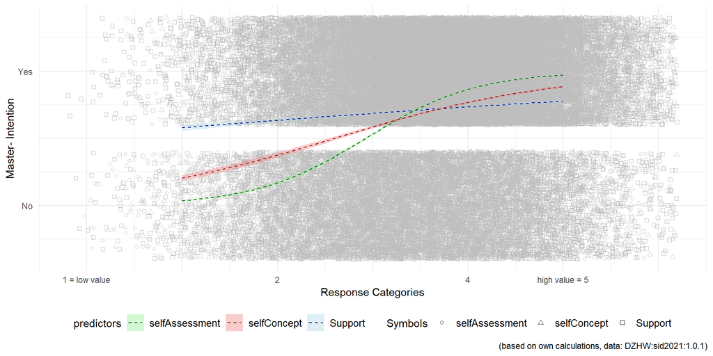

```r
plotAllData <- ggplot(data = data) +
  # selfAssessment: circle
  geom_jitter(aes(
    x = selfAssessment, y = intention,
    shape = "selfAssessment"),
    alpha = 0.8, width = 1.2, height = 0.4,
    color = "grey") +
  # selfConcept: triangle
  geom_jitter(aes(
    x = selfConcept, y = intention,
    shape = "selfConcept"),
    alpha = 0.8, width = 1.2, height = 0.4,
    color = "grey") +
  # support: square
  geom_jitter(aes(
    x = support, y = intention, shape = "Support"),
    alpha = 1, width = 1.2, height = 0.4,
    color = "grey") +
  # support regression line
  geom_smooth(aes(
    x = support, y = intention, color = "Support"),
    method = "glm",
    method.args = list(family = "binomial"),
    fill = "lightblue",
    linewidth = 0.5, linetype = "dashed",
    fullrange = TRUE) +
  # selfAssessment
  geom_smooth(aes(
    x = selfAssessment, y = intention,
    color = "selfAssessment"),
    method = "glm",
    method.args = list(family = "binomial"),
    fill = "lightgreen",
    linewidth = 0.5, linetype = "dashed",
    fullrange = TRUE) +
  # selfConcept
  geom_smooth(aes(
    x = selfConcept, y = intention,
    color = "selfConcept"),
    method = "glm",
    method.args = list(family = "binomial"),
    fill = "lightcoral",
    linewidth = 0.5, linetype = "dashed",
    fullrange = TRUE) +

  ylab("Master- Intention") +
  xlab("Response Categories") +
  labs(caption = "(based on own calculations, data: DZHW:sid2021:1.0.1)") +
  scale_color_manual(name = "predictors",
        values = c("Support" = "darkblue",
                   "selfAssessment" = "darkgreen",
                   "selfConcept" = "darkred"),
        guide = guide_legend(order = 1)) +
  scale_shape_manual(name = "Symbols",
        values = c("Support" = 0,
                   "selfAssessment" = 1,
                   "selfConcept" = 2),
        guide = guide_legend(order = 2,
                override.aes = list(color = "black"))) +
  scale_y_continuous(breaks = c(0, 0.5, 1),
                     labels = c("No", "", "Yes")) +
  scale_x_continuous(breaks = c(0, 1, 2, 3, 4, 5, 6),
                     labels = c("1 = low value", "", "2",
                                "", "4","high value = 5","")) +
  theme_minimal() +
  theme(
    legend.position = "bottom",
    legend.box = "horizontal",
    legend.text = element_text(size = 10))

plotAllData
```

### 7.2 sample, n = 2000

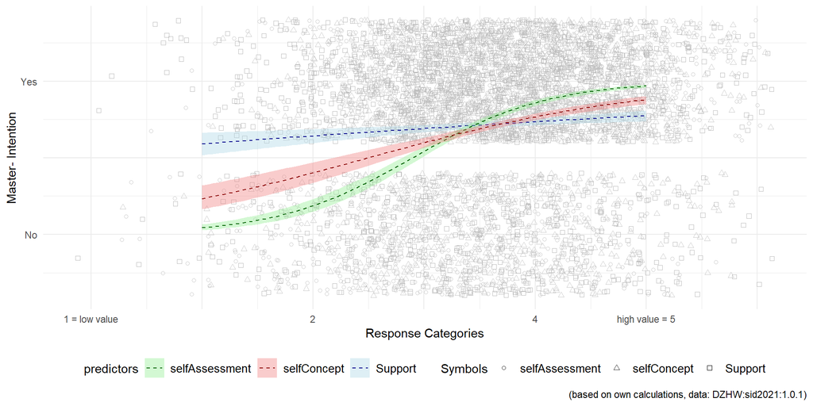

```r
set.seed(2601)
sample_data <- sample_n(data, 2000)

sampleplot <- ggplot(data = sample_data) +

  # selfAssessment: circle
  geom_jitter(aes(
    x = selfAssessment, y = intention,
    shape = "selfAssessment"),
    alpha = 0.8, width = 1.2, height = 0.4,
    color = "grey") +
  # selfConcept: triangle
  geom_jitter(aes(
    x = selfConcept, y = intention,
    shape = "selfConcept"),
    alpha = 0.8, width = 1.2, height = 0.4,
    color = "grey") +
  # support: square
  geom_jitter(aes(
    x = support, y = intention, shape = "Support"),
    alpha = 1, width = 1.2, height = 0.4,
    color = "grey") +
  # support regression line
  geom_smooth(aes(
    x = support, y = intention, color = "Support"),
    method = "glm",
    method.args = list(family = "binomial"),
    fill = "lightblue",
    linewidth = 0.5, linetype = "dashed",
    fullrange = TRUE) +
  # selfAssessment
  geom_smooth(aes(
    x = selfAssessment, y = intention,
    color = "selfAssessment"),
    method = "glm",
    method.args = list(family = "binomial"),
    fill = "lightgreen",
    linewidth = 0.5, linetype = "dashed",
    fullrange = TRUE) +
  # selfConcept
  geom_smooth(aes(
    x = selfConcept, y = intention,
    color = "selfConcept"),
    method = "glm",
    method.args = list(family = "binomial"),
    fill = "lightcoral",
    linewidth = 0.5, linetype = "dashed",
    fullrange = TRUE) +

  ylab("Master- Intention") +
  xlab("Response Categories") +
  labs(caption = "(based on own calculations, data: DZHW:sid2021:1.0.1)") +
  scale_color_manual(name = "predictors",
        values = c("Support" = "darkblue",
                   "selfAssessment" = "darkgreen",
                   "selfConcept" = "darkred"),
        guide = guide_legend(order = 1)) +
  scale_shape_manual(name = "Symbols",
        values = c("Support" = 0,
                   "selfAssessment" = 1,
                   "selfConcept" = 2),
        guide = guide_legend(order = 2,
                override.aes = list(color = "black"))) +
  scale_y_continuous(breaks = c(0, 0.5, 1),
        labels = c("No", "", "Yes")) +
  scale_x_continuous(breaks = c(0, 1, 2, 3, 4, 5, 6),
         labels = c("1 = low value", "", "2",
                     "", "4","high value = 5","")) +
  theme_minimal() +
  theme(
    legend.position = "bottom",
    legend.box = "horizontal",
    legend.text = element_text(size = 10))


sampleplot
```

## 8 Stratification

### 8.1 Predictor Distributions

```r
descriptive_stats <- data |>
  group_by(intention) |>
  summarise(
    Mean_selfAss = mean(selfAssessment),
    SD_selfAssess = sd(selfAssessment),
    Mean_selfConc = mean(selfConcept),
    SD_selfConc = sd(selfConcept),
    Mean_support = mean(support),
    SD_support = sd(support),
    Count = n())

descriptive_stats
```

```
## # A tibble: 2 × 8
##   intention Mean_selfAss SD_selfAssess Mean_selfConc SD_selfConc Mean_support
##       <dbl>        <dbl>         <dbl>         <dbl>       <dbl>        <dbl>
## 1         0         3.06         0.735          3.49       0.661         3.44
## 2         1         3.81         0.586          3.82       0.588         3.60
## # ℹ 2 more variables: SD_support <dbl>, Count <int>
```

#### Density Plots

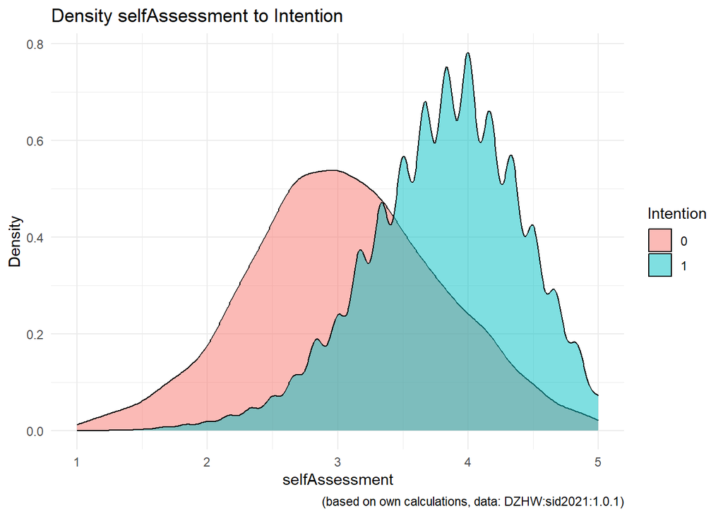

```r
# selfAssessment
ggplot(data, aes(
  x = selfAssessment,
  fill = as.factor(intention))) +
  geom_density(alpha = 0.5) +
  labs(
    title = "Density selfAssessment to Intention",
    x = "selfAssessment",
    y = "Density",
    fill = "Intention"
  ) +
  labs(caption = "(based on own calculations, data: DZHW:sid2021:1.0.1)") +
  theme_minimal()
```

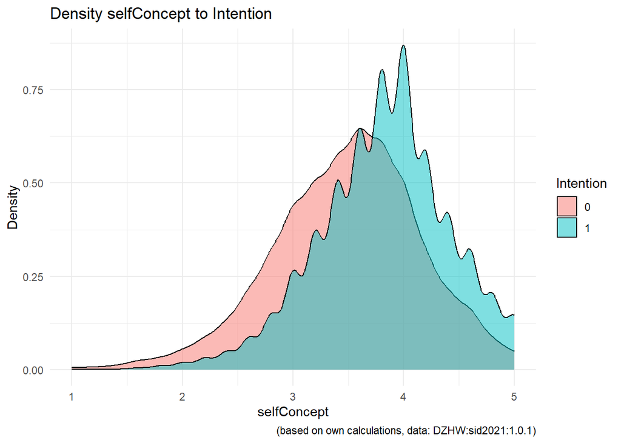

```r
#  selfConcept
ggplot(data, aes(
  x = selfConcept,
  fill = as.factor(intention))) +
  geom_density(alpha = 0.5) +
  labs(
    title = "Density selfConcept to Intention",
    x = "selfConcept",
    y = "Density",
    fill = "Intention"
  ) +
  labs(caption = "(based on own calculations, data: DZHW:sid2021:1.0.1)") +
  theme_minimal()
```

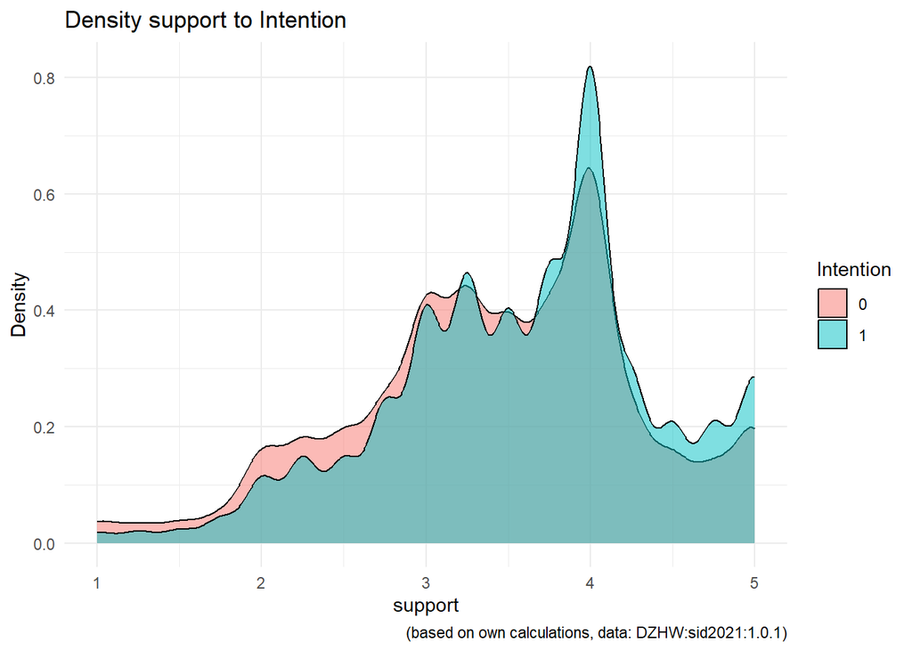

```r
# support
ggplot(data, aes(
  x = support,
  fill = as.factor(intention))) +
  geom_density(alpha = 0.5) +
  labs(
    title = "Density support to Intention",
    x = "support",
    y = "Density",
    fill = "Intention"
  ) +
  labs(caption = "(based on own calculations, data: DZHW:sid2021:1.0.1)") +
  theme_minimal()
```

### 8.2 Split Confounder Age

```r
attach(data)
frq(age_cat, show.na = FALSE)
```

[output not shown]

#### Density Plot

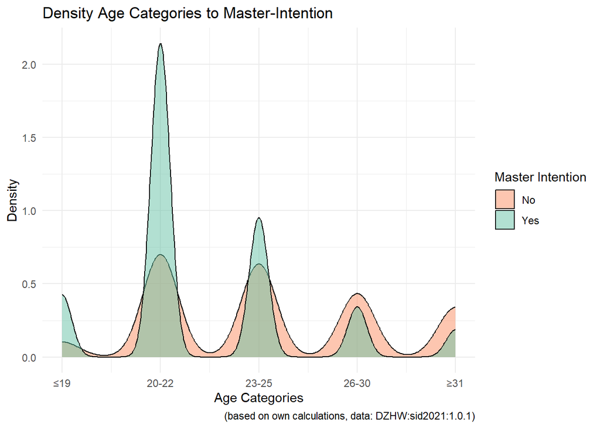

```r
ggplot(data, aes(x = as.numeric(age_cat), fill = factor(intention))) +
  geom_density(alpha = 0.5) +
  labs(
    x = "Age Categories",
    y = "Density",
    fill = "Master Intention",
    title = "Density Age Categories to Master-Intention"
  ) +
  scale_fill_manual(values = c("#fc8d62", "#66c2a5"),
                    labels = c("No", "Yes")) +
  scale_x_continuous(
    breaks = 1:5,
    labels = c("≤19", "20-22", "23-25", "26-30", "≥31")
  ) +
  labs(caption = "(based on own calculations, data: DZHW:sid2021:1.0.1)") +
  theme_minimal()
```

#### Age Categories

```r
ageCat_table <- table(data$age_cat)
ageCat_prop <- prop.table(ageCat_table) * 100
ageCat_cum_prop <- cumsum(ageCat_prop)

ageCat_freq <- data.frame(
  Value = as.numeric(names(ageCat_table)),
  Label = c("19 years and younger",
            "20 - 22 years",
            "23 - 25 years",
            "26 - 30 years",
            "31 years and older"),
  N = as.vector(ageCat_table),
  Raw_Percent = round(as.numeric(ageCat_prop), 2),
  Valid_Percent = round(as.numeric(ageCat_prop), 2),
  Cumulative_Percent = round(as.numeric(ageCat_cum_prop), 2))



kableExtra::kable(ageCat_freq, format = "html",
      col.names = c("Value", "Label", "N", "Raw %", "Valid %", "Cum. %"),
      caption = "Age Categories")  |>
  kable_styling(bootstrap_options = c(
    "striped", "hover", "condensed", "responsive"),
                full_width = F)  |>
  #column_spec(1, bold = TRUE) |>
  #column_spec(3:6, color = "blue") |>
  add_header_above(c(" ", "Frequencies Age Categories" = 5))
```

Age Categories

| Value | Frequencies Age Categories Label | Frequencies Age Categories N | Frequencies Age Categories Raw % | Frequencies Age Categories Valid % | Frequencies Age Categories Cum. % |
| --- | --- | --- | --- | --- | --- |
| 1 | 19 years and younger | 1840 | 8.81 | 8.81 | 8.81 |
| 2 | 20 - 22 years | 9768 | 46.76 | 46.76 | 55.56 |
| 3 | 23 - 25 years | 5227 | 25.02 | 25.02 | 80.58 |
| 4 | 26 - 30 years | 2443 | 11.69 | 11.69 | 92.28 |
| 5 | 31 years and older | 1613 | 7.72 | 7.72 | 100.00 |

### 8.3 Chi² Test

```r
tableAgeInt <- table(data$age_cat, data$intention)
tableAgeInt
```

```
##
##        0    1
##   1  280 1560
##   2 1913 7855
##   3 1736 3491
##   4 1184 1259
##   5  927  686
```

```r
chi_square_test <- chisq.test(tableAgeInt)
chi_square_test
```

```
##
##  Pearson's Chi-squared test
##
## data:  tableAgeInt
## X-squared = 1722.9, df = 4, p-value < 2.2e-16
```

## 9 Regression Factor Model

```r
glm_ageCat <- glm(
  intention ~ selfAssessment + selfConcept + support +
    factor(age_cat) + parentsEducation + study,
  family = binomial,
  data = data)

robust_se_ageCat <- lmtest::coeftest(
  glm_ageCat,
  vcov = sandwich::vcovHC(
    glm_ageCat, type = "HC1"))

texreg::screenreg(
  list(glm_ageCat),
  override.se = list(
    robust_se_ageCat[, "Std. Error"]),
  override.pvalues = list(
    robust_se_ageCat[, "Pr(>|z|)"]))
```

```
##
## ==============================
##                   Model 1
## ------------------------------
## (Intercept)          -3.58 ***
##                      (0.15)
## selfAssessment        2.01 ***
##                      (0.04)
## selfConcept          -0.43 ***
##                      (0.04)
## support              -0.06 **
##                      (0.02)
## factor(age_cat)2     -0.41 ***
##                      (0.08)
## factor(age_cat)3     -1.10 ***
##                      (0.08)
## factor(age_cat)4     -1.70 ***
##                      (0.09)
## factor(age_cat)5     -2.15 ***
##                      (0.09)
## parentsEducation      0.39 ***
##                      (0.04)
## study                 0.17 ***
##                      (0.04)
## ------------------------------
## AIC               18471.99
## BIC               18551.46
## Log Likelihood    -9226.00
## Deviance          18451.99
## Num. obs.         20891
## ==============================
## *** p < 0.001; ** p < 0.01; * p < 0.05
```

## 10 separate Regressions GLM

Stratification to sub categories

```r
data_age_cat1 <- subset(data, age_cat == 1)
data_age_cat2 <- subset(data, age_cat == 2)
data_age_cat3 <- subset(data, age_cat == 3)
data_age_cat4 <- subset(data, age_cat == 4)
data_age_cat5 <- subset(data, age_cat == 5)
```

### 10.1 Separate Models

category 1

```r
model_age_cat1 <- glm(intention ~ selfAssessment +
                        selfConcept + support +
                        parentsEducation + study,
                      data = data_age_cat1, family = binomial)

robust_se_age1 <- lmtest::coeftest(model_age_cat1,
  vcov = sandwich::vcovHC(model_age_cat1, type = "HC1"))

z_values <- robust_se_age1[, "Estimate"] / robust_se_age1[, "Std. Error"]

p_values <- 2 * (1 - pnorm(abs(z_values)))

# texreg::screenreg(
#   list(model_age_cat1),
#   override.se = list(
#     robust_se_age1[, "Std. Error"]),
#   override.pvalues = list(
#     robust_se_age1[, "Pr(>|z|)"]),
#   custom.model.names = c("Age <= 19 years"))
```

category 2

```r
model_age_cat2 <- glm(
  intention ~ selfAssessment +
    selfConcept + support +
    parentsEducation + study,
  data = data_age_cat2,
  family = binomial)

robust_se_age2 <- lmtest::coeftest(model_age_cat2,
  vcov = sandwich::vcovHC(model_age_cat2, type = "HC1"))

#z_values <- robust_se_age2[, "Estimate"] / robust_se_age2[, "Std. Error"]

#p_values <- 2 * (1 - pnorm(abs(z_values)))


# texreg::screenreg(
#   list(model_age_cat2),
#   override.se = list(
#     robust_se_age2[, "Std. Error"]),
#   override.pvalues = list(
#     robust_se_age2[, "Pr(>|z|)"]),
#   custom.model.names = c("Age 20 to 22 years"))
```

category 3

```r
model_age_cat3 <- glm(
  intention ~ selfAssessment +
    selfConcept + support +
    parentsEducation + study,
  data = data_age_cat3,
  family = binomial)

robust_se_age3 <- lmtest::coeftest(model_age_cat3,
  vcov = sandwich::vcovHC(model_age_cat3, type = "HC1"))

#z_values <- robust_se_age3[, "Estimate"] / robust_se_age3[, "Std. Error"]

#p_values <- 2 * (1 - pnorm(abs(z_values)))


# texreg::screenreg(
#   list(model_age_cat3),
#   override.se = list(
#     robust_se_age3[, "Std. Error"]),
#   override.pvalues = list(
#     robust_se_age3[, "Pr(>|z|)"]),
#   custom.model.names = c("Age 23 to 25 years"))
```

category 4

```r
model_age_cat4 <- glm(
  intention ~ selfAssessment +
    selfConcept + support +
    parentsEducation + study,
  data = data_age_cat4,
  family = binomial)

robust_se_age4 <- lmtest::coeftest(model_age_cat4,
  vcov = sandwich::vcovHC(model_age_cat4, type = "HC1"))

#z_values <- robust_se_age3[, "Estimate"] / robust_se_age3[, "Std. Error"]

#p_values <- 2 * (1 - pnorm(abs(z_values)))


# texreg::screenreg(
#   list(model_age_cat4),
#   override.se = list(
#     robust_se_age4[, "Std. Error"]),
#   override.pvalues = list(
#     robust_se_age4[, "Pr(>|z|)"]),
#   custom.model.names = c("Age 26 to 30 years")
#   )
```

category 5

```r
model_age_cat5 <- glm(
  intention ~ selfAssessment +
    selfConcept + support +
    parentsEducation + study,
  data = data_age_cat5,
  family = binomial)

robust_se_age5 <- lmtest::coeftest(model_age_cat5,
  vcov = sandwich::vcovHC(model_age_cat5, type = "HC1"))

#z_values <- robust_se_age3[, "Estimate"] / robust_se_age3[, "Std. Error"]

#p_values <- 2 * (1 - pnorm(abs(z_values)))


# texreg::screenreg(
#   list(model_age_cat5),
#   override.se = list(
#     robust_se_age5[, "Std. Error"]),
#   override.pvalues = list(
#     robust_se_age5[, "Pr(>|z|)"]),
#   custom.model.names = c("Age >= 31 years"))
```

### 10.2 Comparison

```r
outputM <- texreg::screenreg(
  list(model_age_cat1, model_age_cat2, model_age_cat3, model_age_cat4, model_age_cat5),
  override.se = list(robust_se_age1[, "Std. Error"], robust_se_age2[, "Std. Error"], robust_se_age3[, "Std. Error"], robust_se_age4[, "Std. Error"], robust_se_age5[, "Std. Error"]),
  override.pvalues = list(robust_se_age1[, "Pr(>|z|)"], robust_se_age2[, "Pr(>|z|)"], robust_se_age3[, "Pr(>|z|)"], robust_se_age4[, "Pr(>|z|)"], robust_se_age5[, "Pr(>|z|)"]),
  custom.model.names = c("Age <= 19 years", "Age 20 to 22 years", "Age 23 to 25 years", "Age 26 to 30 years", "Age >= 31 years")
)

outputM
```

```
##
## ==============================================================================================================
##                   Age <= 19 years  Age 20 to 22 years  Age 23 to 25 years  Age 26 to 30 years  Age >= 31 years
## --------------------------------------------------------------------------------------------------------------
## (Intercept)         -4.11 ***         -4.21 ***           -4.46 ***           -4.67 ***          -6.05 ***
##                     (0.55)            (0.21)              (0.24)              (0.34)             (0.46)
## selfAssessment       2.38 ***          2.09 ***            1.96 ***            1.93 ***           1.71 ***
##                     (0.17)            (0.07)              (0.08)              (0.10)             (0.12)
## selfConcept         -0.51 **          -0.46 ***           -0.43 ***           -0.58 ***          -0.10
##                     (0.16)            (0.06)              (0.07)              (0.10)             (0.13)
## support             -0.21 *           -0.08 *             -0.07                0.02              -0.00
##                     (0.10)            (0.04)              (0.04)              (0.05)             (0.07)
## parentsEducation     0.67 ***          0.45 ***            0.39 ***            0.27 **            0.07
##                     (0.15)            (0.06)              (0.07)              (0.10)             (0.12)
## study                0.09              0.31 ***            0.03                0.06               0.21
##                     (0.15)            (0.06)              (0.07)              (0.10)             (0.12)
## --------------------------------------------------------------------------------------------------------------
## AIC               1160.04           7534.41             5298.50             2702.92            1764.59
## BIC               1193.15           7577.53             5337.87             2737.73            1796.91
## Log Likelihood    -574.02          -3761.20            -2643.25            -1345.46            -876.30
## Deviance          1148.04           7522.41             5286.50             2690.92            1752.59
## Num. obs.         1840              9768                5227                2443               1613
## ==============================================================================================================
## *** p < 0.001; ** p < 0.01; * p < 0.05
```

```r
write.table(outputM, "regrOutput.txt")
```

### 10.3 McFadden R²

```r
# Funktion zur Berechnung des McFadden R²
mcfadden_r2 <- function(model) {
  ll_full <- logLik(model)
  ll_null <- logLik(update(model, . ~ 1))
  return(1 - as.numeric(ll_full / ll_null))
}

r2_age_cat1 <- mcfadden_r2(model_age_cat1)
r2_age_cat2 <- mcfadden_r2(model_age_cat2)
r2_age_cat3 <- mcfadden_r2(model_age_cat3)
r2_age_cat4 <- mcfadden_r2(model_age_cat4)
r2_age_cat5 <- mcfadden_r2(model_age_cat5)


cat("McFadden R² Model 1 (Age <= 19 years):", r2_age_cat1, "\n")
```

```
## McFadden R² Model 1 (Age <= 19 years): 0.2684721
```

```r
cat("McFadden R² Model 2 (Age 20 to 22 years):", r2_age_cat2, "\n")
```

```
## McFadden R² Model 2 (Age 20 to 22 years): 0.221463
```

```r
cat("McFadden R² Model 3 (Age 23 to 25 years):", r2_age_cat3, "\n")
```

```
## McFadden R² Model 3 (Age 23 to 25 years): 0.2044763
```

```r
cat("McFadden R² Model 4 (Age 26 to 30 years):", r2_age_cat4, "\n")
```

```
## McFadden R² Model 4 (Age 26 to 30 years): 0.2049085
```

```r
cat("McFadden R² Model 5 (Age >= 31 years):", r2_age_cat5, "\n")
```

```
## McFadden R² Model 5 (Age >= 31 years): 0.2033492
```

### 10.4 Odds Ratios

```r
models <- lapply(1:5, function(i) {
  glm(intention ~ selfAssessment + selfConcept + support +
        parentsEducation + study,
      data = subset(data, age_cat == i), family = binomial)
})


odds_ratios_with_ci <- lapply(models, function(model) {
  exp(cbind(OR = coef(model), confint(model)))
})

results_list <- lapply(1:5, function(i) {
  data.frame(
    Model = paste("Cat.", i),
    Variable = rownames(odds_ratios_with_ci[[i]]),
    Odds_Ratio = odds_ratios_with_ci[[i]][, "OR"],
    CI_Lower = odds_ratios_with_ci[[i]][, "2.5 %"],
    CI_Upper = odds_ratios_with_ci[[i]][, "97.5 %"]
  )
})

results_df <- do.call(rbind, results_list)
```

output:

```r
# Cat1
results_age_cat1 <- subset(
  results_df, Model == "Cat. 1") |>
  select(Variable, Odds_Ratio, CI_Lower, CI_Upper) |>
  kable(format = "html",
        col.names = c("Variable", "Odds Ratio", "CI Lower", "CI Upper"),
        caption = "Odds Ratios Age <= 19 years") |>
  kable_styling(bootstrap_options = c("striped", "hover", "condensed", "responsive"),
                full_width = FALSE)
results_age_cat1
```

Odds Ratios Age <= 19 years

|  | Variable | Odds Ratio | CI Lower | CI Upper |
| --- | --- | --- | --- | --- |
| (Intercept) | (Intercept) | 0.0164419 | 0.0056120 | 0.0470944 |
| selfAssessment | selfAssessment | 10.8446447 | 7.8989100 | 15.1354071 |
| selfConcept | selfConcept | 0.6000992 | 0.4411264 | 0.8119712 |
| support | support | 0.8084447 | 0.6670539 | 0.9771471 |
| parentsEducation | parentsEducation | 1.9587461 | 1.4499969 | 2.6467580 |
| study | study | 1.0940056 | 0.8092605 | 1.4816223 |

```r
# Cat2
results_age_cat2 <- subset(results_df, Model == "Cat. 2") |>
  select(Variable, Odds_Ratio, CI_Lower, CI_Upper) |>
  kable(format = "html",
        col.names = c("Variable", "Odds Ratio", "CI Lower", "CI Upper"),
        caption = "Odds Ratios Age 20 to 22 years") |>
  kable_styling(bootstrap_options = c("striped", "hover", "condensed", "responsive"),
                full_width = FALSE)
results_age_cat2
```

Odds Ratios Age 20 to 22 years

|  | Variable | Odds Ratio | CI Lower | CI Upper |
| --- | --- | --- | --- | --- |
| (Intercept)1 | (Intercept) | 0.0148305 | 0.0098420 | 0.0222510 |
| selfAssessment1 | selfAssessment | 8.1223460 | 7.1897284 | 9.1956225 |
| selfConcept1 | selfConcept | 0.6333348 | 0.5597938 | 0.7160104 |
| support1 | support | 0.9189756 | 0.8550843 | 0.9873191 |
| parentsEducation1 | parentsEducation | 1.5621650 | 1.3929530 | 1.7520692 |
| study1 | study | 1.3597078 | 1.2076935 | 1.5319113 |

```r
# Cat3
results_age_cat3 <- subset(results_df, Model == "Cat. 3") |>
  select(Variable, Odds_Ratio, CI_Lower, CI_Upper) |>
  kable(format = "html",
        col.names = c("Variable", "Odds Ratio", "CI Lower", "CI Upper"),
        caption = "Odds Ratios Age 23 to 25 years") |>
  kable_styling(bootstrap_options = c("striped", "hover", "condensed", "responsive"),
                full_width = FALSE)
results_age_cat3
```

Odds Ratios Age 23 to 25 years

|  | Variable | Odds Ratio | CI Lower | CI Upper |
| --- | --- | --- | --- | --- |
| (Intercept)2 | (Intercept) | 0.0115734 | 0.0070840 | 0.0187682 |
| selfAssessment2 | selfAssessment | 7.1113636 | 6.1881512 | 8.1965201 |
| selfConcept2 | selfConcept | 0.6512300 | 0.5664326 | 0.7479772 |
| support2 | support | 0.9305808 | 0.8569299 | 1.0102522 |
| parentsEducation2 | parentsEducation | 1.4800567 | 1.2956166 | 1.6913270 |
| study2 | study | 1.0344034 | 0.9035518 | 1.1846373 |

```r
# Cat4
results_age_cat4 <- subset(results_df, Model == "Cat. 4") |>
  select(Variable, Odds_Ratio, CI_Lower, CI_Upper) |>
  kable(format = "html",
        col.names = c("Variable", "Odds Ratio", "CI Lower", "CI Upper"),
        caption = "Odds Ratios Age 26 to 30 years") |>
  kable_styling(bootstrap_options = c("striped", "hover", "condensed", "responsive"),
                full_width = FALSE)
results_age_cat4
```

Odds Ratios Age 26 to 30 years

|  | Variable | Odds Ratio | CI Lower | CI Upper |
| --- | --- | --- | --- | --- |
| (Intercept)3 | (Intercept) | 0.0093885 | 0.0048111 | 0.0180391 |
| selfAssessment3 | selfAssessment | 6.9207851 | 5.7199672 | 8.4272476 |
| selfConcept3 | selfConcept | 0.5584210 | 0.4578714 | 0.6793814 |
| support3 | support | 1.0163663 | 0.9127520 | 1.1315756 |
| parentsEducation3 | parentsEducation | 1.3148116 | 1.0901943 | 1.5861680 |
| study3 | study | 1.0566112 | 0.8751505 | 1.2761051 |

```r
# Cat5
results_age_cat5 <- subset(results_df, Model == "Cat. 5") |>
  select(Variable, Odds_Ratio, CI_Lower, CI_Upper) |>
  kable(format = "html",
        col.names = c("Variable", "Odds Ratio", "CI Lower", "CI Upper"),
        caption = "Odds Ratios Age >= 31 years") |>
  kable_styling(bootstrap_options = c("striped", "hover", "condensed", "responsive"),
                full_width = FALSE)
results_age_cat5
```

Odds Ratios Age >= 31 years

|  | Variable | Odds Ratio | CI Lower | CI Upper |
| --- | --- | --- | --- | --- |
| (Intercept)4 | (Intercept) | 0.0023578 | 0.0009474 | 0.0056906 |
| selfAssessment4 | selfAssessment | 5.5264376 | 4.4316084 | 6.9451470 |
| selfConcept4 | selfConcept | 0.9087410 | 0.7102155 | 1.1620706 |
| support4 | support | 0.9951009 | 0.8739962 | 1.1329420 |
| parentsEducation4 | parentsEducation | 1.0718626 | 0.8465304 | 1.3562183 |
| study4 | study | 1.2359736 | 0.9680355 | 1.5791155 |

### 10.5 AME’s

```r
display_ame_summary <- function(
    summary_object, model_name) {
  summary_object |>
    as.data.frame() |>
    kbl(caption = paste(
      "AME Summary for", model_name)) |>
    kable_styling(bootstrap_options = c(
      "striped", "hover", "condensed", "responsive"))
}

ame_age_cat1 <- margins::margins(model_age_cat1)
ame_age_cat2 <- margins::margins(model_age_cat2)
ame_age_cat3 <- margins::margins(model_age_cat3)
ame_age_cat4 <- margins::margins(model_age_cat4)
ame_age_cat5 <- margins::margins(model_age_cat5)


# summary(ame_age_cat1)
# summary(ame_age_cat2)
# summary(ame_age_cat3)
# summary(ame_age_cat4)
# summary(ame_age_cat5)


display_ame_summary(
  summary(ame_age_cat1), "Age <= 19 years")
```

AME Summary for Age <= 19 years

| factor | AME | SE | z | p | lower | upper |
| --- | --- | --- | --- | --- | --- | --- |
| parentsEducation | 0.0632035 | 0.0142390 | 4.4387485 | 0.0000090 | 0.0352955 | 0.0911115 |
| selfAssessment | 0.2240896 | 0.0130536 | 17.1668923 | 0.0000000 | 0.1985050 | 0.2496742 |
| selfConcept | -0.0480073 | 0.0145056 | -3.3095750 | 0.0009344 | -0.0764377 | -0.0195769 |
| study | 0.0084464 | 0.0144911 | 0.5828709 | 0.5599802 | -0.0199556 | 0.0368484 |
| support | -0.0199906 | 0.0091133 | -2.1935767 | 0.0282659 | -0.0378523 | -0.0021290 |

```r
display_ame_summary(
  summary(ame_age_cat2), "Age 20 to 22 years")
```

AME Summary for Age 20 to 22 years

| factor | AME | SE | z | p | lower | upper |
| --- | --- | --- | --- | --- | --- | --- |
| parentsEducation | 0.0534366 | 0.0069544 | 7.683796 | 0.0000000 | 0.0398061 | 0.0670670 |
| selfAssessment | 0.2509215 | 0.0061315 | 40.923237 | 0.0000000 | 0.2389039 | 0.2629390 |
| selfConcept | -0.0547164 | 0.0074569 | -7.337701 | 0.0000000 | -0.0693316 | -0.0401011 |
| study | 0.0368089 | 0.0072433 | 5.081806 | 0.0000004 | 0.0226123 | 0.0510054 |
| support | -0.0101220 | 0.0043909 | -2.305212 | 0.0211547 | -0.0187281 | -0.0015160 |

```r
display_ame_summary(
  summary(ame_age_cat3), "Age 23 to 25 years")
```

AME Summary for Age 23 to 25 years

| factor | AME | SE | z | p | lower | upper |
| --- | --- | --- | --- | --- | --- | --- |
| parentsEducation | 0.0653870 | 0.0112227 | 5.8263087 | 0.0000000 | 0.0433909 | 0.0873832 |
| selfAssessment | 0.3271506 | 0.0085994 | 38.0434566 | 0.0000000 | 0.3102961 | 0.3440051 |
| selfConcept | -0.0715262 | 0.0116817 | -6.1229210 | 0.0000000 | -0.0944219 | -0.0486304 |
| study | 0.0056410 | 0.0115209 | 0.4896276 | 0.6243974 | -0.0169396 | 0.0282215 |
| support | -0.0119985 | 0.0069951 | -1.7152646 | 0.0862967 | -0.0257086 | 0.0017117 |

```r
display_ame_summary(
  summary(ame_age_cat4), "Age 26 to 30 years")
```

AME Summary for Age 26 to 30 years

| factor | AME | SE | z | p | lower | upper |
| --- | --- | --- | --- | --- | --- | --- |
| parentsEducation | 0.0507864 | 0.0176408 | 2.8789116 | 0.0039905 | 0.0162110 | 0.0853619 |
| selfAssessment | 0.3589704 | 0.0124350 | 28.8677374 | 0.0000000 | 0.3345983 | 0.3833426 |
| selfConcept | -0.1081149 | 0.0182381 | -5.9279667 | 0.0000000 | -0.1438609 | -0.0723688 |
| study | 0.0102182 | 0.0178447 | 0.5726178 | 0.5669035 | -0.0247568 | 0.0451931 |
| support | 0.0030123 | 0.0101679 | 0.2962587 | 0.7670326 | -0.0169164 | 0.0229411 |

```r
display_ame_summary(
  summary(ame_age_cat5), "Age >= 31 years")
```

AME Summary for Age >= 31 years

| factor | AME | SE | z | p | lower | upper |
| --- | --- | --- | --- | --- | --- | --- |
| parentsEducation | 0.0126845 | 0.0219575 | 0.5776848 | 0.5634770 | -0.0303514 | 0.0557204 |
| selfAssessment | 0.3124690 | 0.0150753 | 20.7272669 | 0.0000000 | 0.2829221 | 0.3420160 |
| selfConcept | -0.0174911 | 0.0229251 | -0.7629659 | 0.4454838 | -0.0624235 | 0.0274413 |
| study | 0.0387234 | 0.0227395 | 1.7029184 | 0.0885833 | -0.0058451 | 0.0832919 |
| support | -0.0008977 | 0.0120924 | -0.0742332 | 0.9408248 | -0.0245984 | 0.0228031 |

## 11 Visualisation Result

### 11.1 Coefficients’ Plot

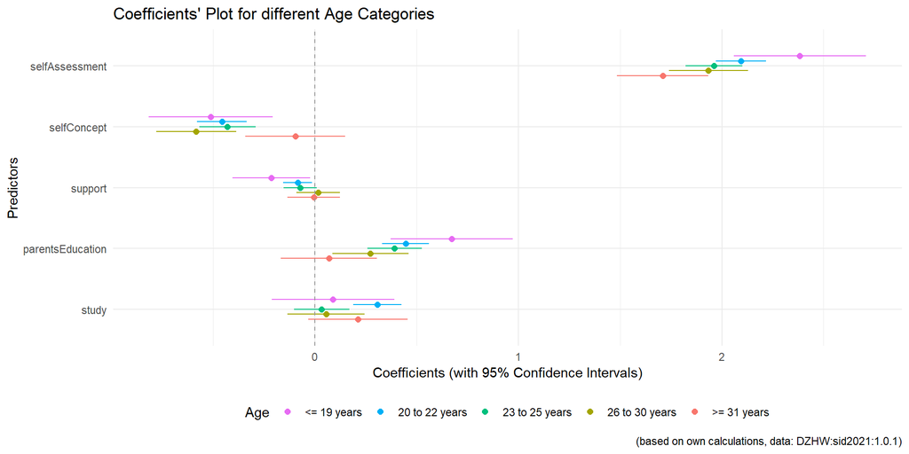

```r
tidy_models <- bind_rows(
  tidy(model_age_cat1) |> mutate(model = "<= 19 years"),
  tidy(model_age_cat2) |> mutate(model = "20 to 22 years"),
  tidy(model_age_cat3) |> mutate(model = "23 to 25 years"),
  tidy(model_age_cat4) |> mutate(model = "26 to 30 years"),
  tidy(model_age_cat5) |> mutate(model = ">= 31 years")
)


tidy_models <- tidy_models |>
  filter(term %in% c("selfAssessment", "selfConcept", "support",
                     "parentsEducation", "study"))

dwplot(tidy_models,
       dot_args = list(aes(color = model), size = 2), whisker_args = list(aes(color = model))) + theme_minimal() +
  labs(
  title = "Coefficients' Plot for different Age Categories",
  x = "Coefficients (with 95% Confidence Intervals)",
  y = "Predictors", color = "Age",
  caption = "(based on own calculations, data: DZHW:sid2021:1.0.1)") +
  theme(legend.position = "bottom") +
  geom_vline(xintercept = 0, colour = "grey60", linetype = 2)
```

### 11.2 Forest Plot of Odds Ratios

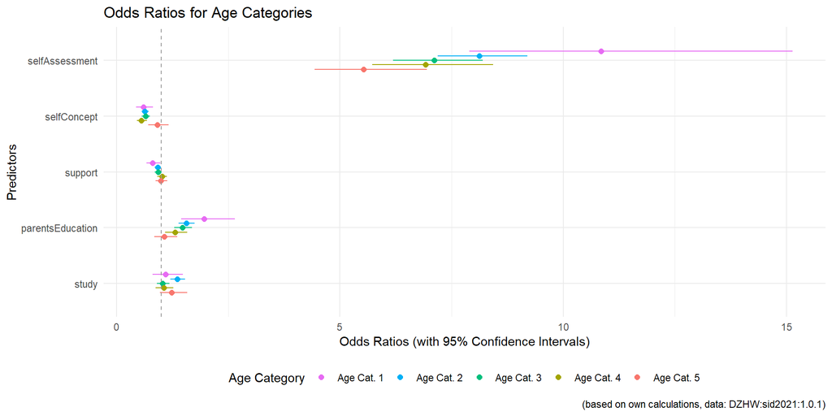

```r
create_tidy_or <- function(model, age_cat) {
  tidy_model <- tidy(model) %>% mutate(model = paste("Age Cat.", age_cat))
  conf_int <- confint(model) %>% as.data.frame() %>%
    rename(conf.low = `2.5 %`, conf.high = `97.5 %`) %>%
    mutate(term = row.names(.))
  tidy_model <- inner_join(tidy_model, conf_int, by = "term")
  tidy_model %>%
    mutate(estimate = exp(estimate),
           conf.low = exp(conf.low),
           conf.high = exp(conf.high)) %>%
    filter(term %in% c("selfAssessment", "selfConcept", "support",
                       "parentsEducation", "study"))
}

tidy_models_or <- bind_rows(
  create_tidy_or(model_age_cat1, 1),
  create_tidy_or(model_age_cat2, 2),
  create_tidy_or(model_age_cat3, 3),
  create_tidy_or(model_age_cat4, 4),
  create_tidy_or(model_age_cat5, 5)
)

dwplot(tidy_models_or,
       dot_args = list(aes(color = model), size = 2),
       whisker_args = list(aes(color = model))) +
  theme_minimal() +
  labs(title = "Odds Ratios for Age Categories",
       x = "Odds Ratios (with 95% Confidence Intervals)",
       y = "Predictors",
       color = "Age Category",
       caption = "(based on own calculations, data: DZHW:sid2021:1.0.1)") +
  theme(legend.position = "bottom") +
  geom_vline(xintercept = 1, colour = "grey60", linetype = 2)
```

### 11.3 Lollipop Chart Odds Ratios

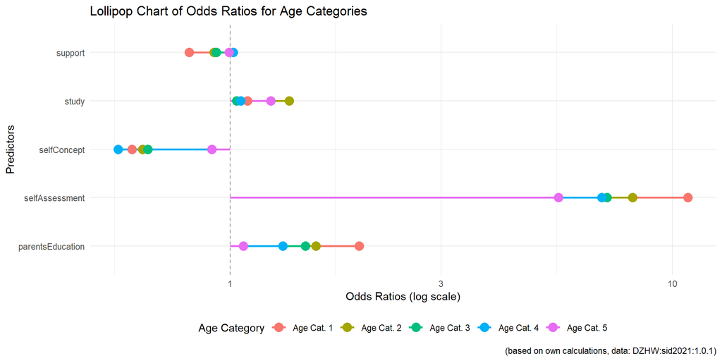

```r
ggplot(tidy_models_or, aes(x = term,
      y = estimate, color = model)) +
  geom_segment(aes(xend = term, yend = 1), size = 1) +
  geom_point(size = 4) +
  scale_y_log10() +
  labs(title = "Lollipop Chart of Odds Ratios for Age Categories",
       x = "Predictors",
       y = "Odds Ratios (log scale)",
       color = "Age Category",
       caption = "(based on own calculations, data: DZHW:sid2021:1.0.1)") +
  theme_minimal() +
  theme(legend.position = "bottom") +
  coord_flip() +
  geom_hline(yintercept = 1, colour = "grey60", linetype = 2)
```

### 11.4 Dot Plot Odds Ratios

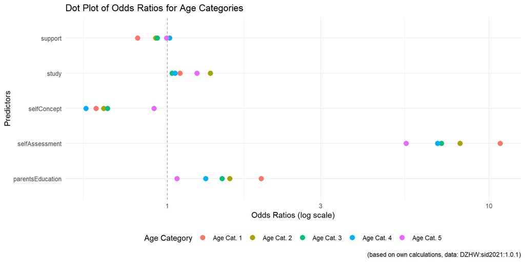

```r
ggplot(tidy_models_or, aes(x = estimate, y = term, color = model)) +
  geom_point(size = 3) +
  scale_x_log10() +
  labs(title = "Dot Plot of Odds Ratios for Age Categories",
       x = "Odds Ratios (log scale)",
       y = "Predictors",
       color = "Age Category",
       caption = "(based on own calculations, data: DZHW:sid2021:1.0.1)") +
  theme_minimal() +
  theme(legend.position = "bottom") +
  geom_vline(xintercept = 1, colour = "grey60", linetype = 2)
```

### 11.5 Plot AME’s

```r
plot_ame <- function(
    ame_summary, model_name) {
  ame_df <- as.data.frame(ame_summary)
  ggplot(ame_df, aes(
    x = factor, y = AME,
    ymin = lower, ymax = upper)) +
    geom_point(size = 3) +
    geom_errorbar(width = 0.2) +
    labs(
      title = paste("Average Marginal Effects for", model_name),
      x = "Predictor",
      y = "Average Marginal Effect",
      caption = "(based on own calculations, data: DZHW:sid2021:1.0.1)") +
    theme_minimal() +
    coord_flip()
}


# plot_ame(summary(ame_age_cat1), "Age <= 19 years")
# plot_ame(summary(ame_age_cat2), "Age 20 to 22 years")
# plot_ame(summary(ame_age_cat3), "Age 23 to 25 years")
# plot_ame(summary(ame_age_cat4), "Age 26 to 30 years")
# plot_ame(summary(ame_age_cat5), "Age >= 31 years")
```

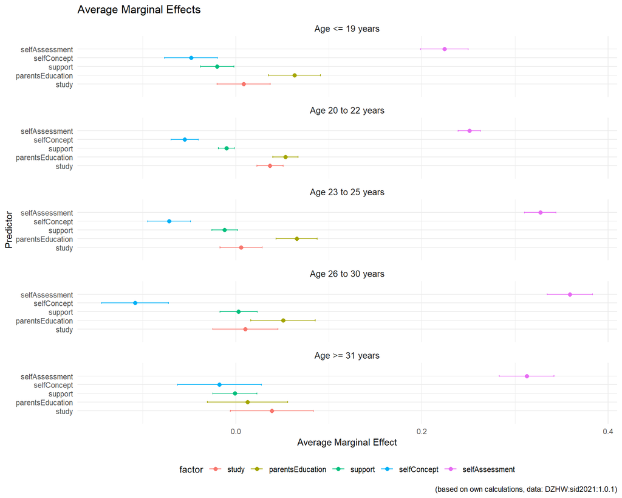

```r
combine_data <- function(ame_summary, model_name) {
  ame_df <- as.data.frame(ame_summary)
  ame_df$model_name <- model_name
  return(ame_df)
}

ame_df_combined <- rbind(
  combine_data(summary(ame_age_cat1), "Age <= 19 years"),
  combine_data(summary(ame_age_cat2), "Age 20 to 22 years"),
  combine_data(summary(ame_age_cat3), "Age 23 to 25 years"),
  combine_data(summary(ame_age_cat4), "Age 26 to 30 years"),
  combine_data(summary(ame_age_cat5), "Age >= 31 years")
)

ame_df_combined$factor <- factor(
  ame_df_combined$factor,
  levels = c( "study", "parentsEducation", "support",
              "selfConcept", "selfAssessment" ))


ame_df_combined$model_name <- factor(
  ame_df_combined$model_name, levels = c(
  "Age <= 19 years",
  "Age 20 to 22 years",
  "Age 23 to 25 years",
  "Age 26 to 30 years",
  "Age >= 31 years"
))



ggplot(ame_df_combined, aes(
  x = factor, y = AME,
  ymin = lower, ymax = upper,
  colour = factor)) +
  geom_point(size = 2, position = position_dodge(width = 3)) +
  geom_errorbar(width = 0.2, position = position_dodge(width = 5)) +
  labs(
    title = "Average Marginal Effects",
    x = "Predictor",
    y = "Average Marginal Effect",
    caption = "(based on own calculations, data: DZHW:sid2021:1.0.1)") +
  theme_minimal() +
  coord_flip() +
  facet_wrap(~ model_name, ncol = 1) +
  theme(legend.position = "bottom",
        strip.text = element_text(size = 10))
```

## 12 Impact of Age

### 12.1 selfAssessment

[figure not shown]

```r
set.seed(42)
data_sim <- tibble(
  intention = rbinom(20891, 1, 0.5),
  selfAssessment = runif(20891, 1, 5),
  selfConcept = runif(20891, 1, 5),
  support = runif(20891, 1, 5),
  study = runif(20891, 1, 5),
  parentsEducation = runif(20891, 1, 5),
  age_cat = sample(1:5, 20891,
            replace = TRUE,
            prob = c(0.09, 0.47, 0.25, 0.12, 0.07)))

model_formula <- intention ~ selfAssessment +
  selfConcept + support + as.factor(age_cat) + parentsEducation + study
model <- glm(model_formula, data = data_sim, family = binomial)

age_categories <- sort(unique(data_sim$age_cat))
self_assessment_vals <- seq(1, 5, length.out = 5)
predict_data <- expand.grid(
  selfAssessment = self_assessment_vals,
  selfConcept = 3,
  support = 3,
  age_cat = age_categories,
  parentsEducation = 3,
  study = 3)

predict_data$predicted_prob <- predict(model,
    newdata = predict_data, type = "response")

predict_data$age_cat <- factor(
  predict_data$age_cat, levels = age_categories)


ggplot(predict_data, aes(
  x = selfAssessment,
  y = predicted_prob,
  color = factor(age_cat),
  shape = factor(age_cat),
  group = factor(age_cat))) +
  geom_line() +
  geom_point(size = 3) +
  scale_color_brewer(palette = "Set1") +
  scale_shape_manual(values = 1:5) +
  labs(
    title = "Predicted Probability of Master Intention by Age Category",
    x = "selfAssessment",
    y = "Predicted Probability",
    color = "Age Category",
    shape = "Age Category",
    caption = "(based on own calculations, data: DZHW:sid2021:1.0.1)") +
  theme_minimal()
```

### 12.2 selfConcept

[figure not shown]

```r
predict_data_selfConcept <- expand.grid(
  selfConcept = seq(1, 5, length.out = 5),
  selfAssessment = 3,
  support = 3,
  age_cat = age_categories,
  parentsEducation = 3,
  study = 3)

predict_data_selfConcept$predicted_prob <- predict(
  model, newdata = predict_data_selfConcept,
  type = "response")

predict_data_selfConcept$age_cat <- factor(
  predict_data_selfConcept$age_cat, levels = age_categories)

ggplot(predict_data_selfConcept, aes(
  x = selfConcept,
  y = predicted_prob,
  color = factor(age_cat),
  shape = factor(age_cat),
  group = factor(age_cat))) +
  geom_line() +
  geom_point(size = 3) +
  scale_color_brewer(palette = "Set1") +
  scale_shape_manual(values = 1:5) +
  labs(
    title = "Predicted Probability of Master Intention by Age Category",
    x = "selfConcept",
    y = "Predicted Probability",
    color = "Age Category",
    shape = "Age Category",
    caption = "(based on own calculations, data: DZHW:sid2021:1.0.1)") +
  theme_minimal()
```

### 12.3 support

[figure not shown]

```r
predict_data_support <- expand.grid(
  support = seq(1, 5, length.out = 5),
  selfAssessment = 3,
  selfConcept = 3,
  age_cat = age_categories,
  parentsEducation = 3,
  study = 3)

predict_data_support$predicted_prob <- predict(
  model, newdata = predict_data_support, type = "response")

predict_data_support$age_cat <- factor(
  predict_data_support$age_cat, levels = age_categories)


ggplot(predict_data_support, aes(
  x = support,
  y = predicted_prob,
  color = factor(age_cat),
  shape = factor(age_cat),
  group = factor(age_cat))) +
  geom_line() +
  geom_point(size = 3) +
  scale_color_brewer(palette = "Set1") +
  scale_shape_manual(values = 1:5) +
  labs(
    title = "Predicted Probability of Master Intention by Age Category",
    x = "Support",
    y = "Predicted Probability",
    color = "Age Category",
    shape = "Age Category",
    caption = "(based on own calculations, data: DZHW:sid2021:1.0.1)") +
  theme_minimal()
```

### 12.4 Predictors under Impact of Age

```r
model_with_age <- glm(
  intention ~ selfAssessment * as.factor(age_cat) +
              selfConcept * as.factor(age_cat) +
              support * as.factor(age_cat) +
              parentsEducation * as.factor(age_cat) +
              study* as.factor(age_cat),
              data = data_sim,
              family = binomial)

robust_se_ageModel <- lmtest::coeftest(
  model_with_age,
  vcov = sandwich::vcovHC(
    model_with_age, type = "HC1"))

# texreg::screenreg(
#   list(model_with_age),
#   override.se = list(
#     robust_se_ageModel[, "Std. Error"]),
#   override.pvalues = list(
#     robust_se_ageModel[, "Pr(>|z|)"]))
```

#### 12.4.1 Plot Impact of Age based on Response Categories

[figure not shown]

```r
model_with_age <- glm(
  intention ~ selfAssessment * as.factor(age_cat) +
              selfConcept * as.factor(age_cat) +
              support * as.factor(age_cat) +
              parentsEducation * as.factor(age_cat) +
              study* as.factor(age_cat),
              data = data_sim,
              family = binomial)


predict_data_selfAssessment <- expand.grid(
  selfAssessment = seq(1, 5, length.out = 5),
  selfConcept = 3,
  support = 3,
  study = 3,
  parentsEducation =3,
  age_cat = age_categories
)
predict_data_selfAssessment$predicted_prob <- predict(
  model_with_age,
  newdata = predict_data_selfAssessment, type = "response")
predict_data_selfAssessment$predictor <- "selfAssessment"
predict_data_selfAssessment$value <- predict_data_selfAssessment$selfAssessment

predict_data_selfConcept <- expand.grid(
  selfConcept = seq(1, 5, length.out = 5),
  selfAssessment = 3,
  support = 3,
  study = 3,
  parentsEducation =3,
  age_cat = age_categories
)
predict_data_selfConcept$predicted_prob <- predict(model_with_age, newdata = predict_data_selfConcept, type = "response")
predict_data_selfConcept$predictor <- "selfConcept"
predict_data_selfConcept$value <- predict_data_selfConcept$selfConcept

predict_data_support <- expand.grid(
  support = seq(1, 5, length.out = 5),
  selfAssessment = 3,
  selfConcept = 3,
  study = 3,
  parentsEducation =3,
  age_cat = age_categories
)
predict_data_support$predicted_prob <- predict(model_with_age, newdata = predict_data_support, type = "response")
predict_data_support$predictor <- "support"
predict_data_support$value <- predict_data_support$support

predict_data_combined <- bind_rows(
  predict_data_selfAssessment,
  predict_data_selfConcept,
  predict_data_support
)

ggplot(predict_data_combined, aes(
  x = value,
  y = predicted_prob,
  color = predictor,
  shape = predictor,
  group = predictor)) +
  geom_line() +
  geom_point(size = 3) +
  scale_color_brewer(palette = "Set1") +
  scale_shape_manual(values = c(1, 2, 3)) +
  labs(
    title = "Impact of Age on the Predicted Probability of Master Intention",
    x = "Response Categories",
    y = "Predicted Probability",
    color = "Predictor",
    shape = "Predictor",
    caption = "(based on own calculations, data: DZHW:sid2021:1.0.1)"
  ) +
  theme_minimal()
```

#### 12.4.2 Plot Impact of Age based on Age Categories

[figure not shown]

```r
model_with_all <- glm(
  intention ~ selfAssessment * as.factor(age_cat) +
                 selfConcept * as.factor(age_cat) +
                 support * as.factor(age_cat) +
                 parentsEducation * as.factor(age_cat) +
                 study * as.factor(age_cat),
                data = data_sim, family = binomial)

predict_data_selfAssessment <- expand.grid(
  selfAssessment = seq(1, 5, length.out = 5),
  selfConcept = 3,
  support = 3,
  study = 3,
  parentsEducation =3,
  age_cat = c(1, 2, 3, 4, 5))

predict_data_selfAssessment$predicted_prob <- predict(
  model_with_all,
newdata = predict_data_selfAssessment, type = "response")
predict_data_selfAssessment$predictor <- "selfAssessment"
predict_data_selfAssessment$value <- predict_data_selfAssessment$selfAssessment


predict_data_selfConcept <- expand.grid(
  selfConcept = seq(1, 5, length.out = 5),
  selfAssessment = 3,
  support = 3,
  study = 3,
  parentsEducation =3,
  age_cat = c(1, 2, 3, 4, 5))

predict_data_selfConcept$predicted_prob <- predict(model_with_all,
  newdata = predict_data_selfConcept, type = "response")
predict_data_selfConcept$predictor <- "selfConcept"
predict_data_selfConcept$value <- predict_data_selfConcept$selfConcept


predict_data_support <- expand.grid(
  support = seq(1, 5, length.out = 5),
  selfAssessment = 3,
  selfConcept = 3,
  study = 3,
  parentsEducation =3,
  age_cat = c(1, 2, 3, 4, 5))

predict_data_support$predicted_prob <- predict(model_with_all,
  newdata = predict_data_support, type = "response")
predict_data_support$predictor <- "support"
predict_data_support$value <- predict_data_support$support

predict_data_combined <- bind_rows(
  predict_data_selfAssessment,
  predict_data_selfConcept,
  predict_data_support)


ggplot(predict_data_combined, aes(
  x = as.factor(age_cat),
  y = predicted_prob,
  color = predictor,
  shape = predictor,
  group = predictor)) +
  geom_line() +
  geom_point(size = 3) +
  scale_color_brewer(palette = "Set1") +
  scale_shape_manual(values = c(1, 2, 3)) +
  scale_x_discrete(labels = c(
    "1" = "<=19", "2" = "20-22",
    "3" = "23-25", "4" = "26-30", "5" = ">=31")) +
  labs(
    title = "Predicted Probability of Master Intention by Predictor and Age Category",
    x = "Age Categories in Years",
    y = "Predicted Probability",
    color = "Predictor",
    shape = "Predictor",
    caption = "(based on own calculations, data: DZHW:sid2021:1.0.1)"
  ) +
  theme_minimal()
```

## 13 Impact of other Confounders

### 13.1 parentsEducation

```r
data_academic <- subset(data, parentsEducation == 1)
data_non_academic <- subset(data, parentsEducation == 0)

model_academic <- glm(intention ~ selfAssessment +
                      selfConcept + support + study,
                      data = data_academic,
                      family = binomial)


model_non_academic <- glm(intention ~ selfAssessment +
                       selfConcept + support + study,
                       data = data_non_academic,
                       family = binomial)


summary_academic <- summary(model_academic)
summary_non_academic <- summary(model_non_academic)


print(summary_academic)
```

```
##
## Call:
## glm(formula = intention ~ selfAssessment + selfConcept + support +
##     study, family = binomial, data = data_academic)
##
## Coefficients:
##                Estimate Std. Error z value Pr(>|z|)
## (Intercept)    -3.72664    0.18030 -20.669  < 2e-16 ***
## selfAssessment  2.00057    0.05396  37.075  < 2e-16 ***
## selfConcept    -0.49943    0.05427  -9.202  < 2e-16 ***
## support        -0.07543    0.03175  -2.375   0.0175 *
## study           0.21091    0.05272   4.000 6.33e-05 ***
## ---
## Signif. codes:  0 '***' 0.001 '**' 0.01 '*' 0.05 '.' 0.1 ' ' 1
##
## (Dispersion parameter for binomial family taken to be 1)
##
##     Null deviance: 11927.3  on 11227  degrees of freedom
## Residual deviance:  9579.9  on 11223  degrees of freedom
## AIC: 9589.9
##
## Number of Fisher Scoring iterations: 5
```

```r
print(summary_non_academic)
```

```
##
## Call:
## glm(formula = intention ~ selfAssessment + selfConcept + support +
##     study, family = binomial, data = data_non_academic)
##
## Coefficients:
##                 Estimate Std. Error z value Pr(>|z|)
## (Intercept)    -4.521659   0.179346 -25.212  < 2e-16 ***
## selfAssessment  2.033924   0.052535  38.716  < 2e-16 ***
## selfConcept    -0.529744   0.052524 -10.086  < 2e-16 ***
## support        -0.001076   0.030016  -0.036 0.971395
## study           0.173721   0.050356   3.450 0.000561 ***
## ---
## Signif. codes:  0 '***' 0.001 '**' 0.01 '*' 0.05 '.' 0.1 ' ' 1
##
## (Dispersion parameter for binomial family taken to be 1)
##
##     Null deviance: 12688  on 9662  degrees of freedom
## Residual deviance: 10066  on 9658  degrees of freedom
## AIC: 10076
##
## Number of Fisher Scoring iterations: 4
```

```r
data_age_cat1_academic <- subset(data, age_cat == 1 & parentsEducation == 1)
data_age_cat1_non_academic <- subset(
  data, age_cat == 1 & parentsEducation == 0)

model_age_cat1_academic <- glm(intention ~ selfAssessment + selfConcept + support,
data = data_age_cat1_academic, family = binomial)
summary(model_age_cat1_academic)
```

```
##
## Call:
## glm(formula = intention ~ selfAssessment + selfConcept + support,
##     family = binomial, data = data_age_cat1_academic)
##
## Coefficients:
##                Estimate Std. Error z value Pr(>|z|)
## (Intercept)     -3.2749     0.6658  -4.919 8.71e-07 ***
## selfAssessment   2.4330     0.2233  10.894  < 2e-16 ***
## selfConcept     -0.6498     0.2104  -3.089  0.00201 **
## support         -0.1541     0.1290  -1.194  0.23247
## ---
## Signif. codes:  0 '***' 0.001 '**' 0.01 '*' 0.05 '.' 0.1 ' ' 1
##
## (Dispersion parameter for binomial family taken to be 1)
##
##     Null deviance: 876.24  on 1230  degrees of freedom
## Residual deviance: 663.50  on 1227  degrees of freedom
## AIC: 671.5
##
## Number of Fisher Scoring iterations: 6
```

```r
model_age_cat1_non_academic <- glm(intention ~ selfAssessment + selfConcept + support,
data = data_age_cat1_non_academic, family = binomial)
summary(model_age_cat1_non_academic)
```

```
##
## Call:
## glm(formula = intention ~ selfAssessment + selfConcept + support,
##     family = binomial, data = data_age_cat1_non_academic)
##
## Coefficients:
##                Estimate Std. Error z value Pr(>|z|)
## (Intercept)     -4.1984     0.8348  -5.029 4.93e-07 ***
## selfAssessment   2.3444     0.2480   9.452  < 2e-16 ***
## selfConcept     -0.3576     0.2287  -1.564   0.1179
## support         -0.2907     0.1481  -1.963   0.0497 *
## ---
## Signif. codes:  0 '***' 0.001 '**' 0.01 '*' 0.05 '.' 0.1 ' ' 1
##
## (Dispersion parameter for binomial family taken to be 1)
##
##     Null deviance: 654.24  on 608  degrees of freedom
## Residual deviance: 483.50  on 605  degrees of freedom
## AIC: 491.5
##
## Number of Fisher Scoring iterations: 5
```

## 14 within-group differences

### 14.1 Age

```r
data_outcomeSplit0 <- subset(data, intention == 0)
data_outcomeSplit1 <- subset(data, intention == 1)

# Distribution of Age within Intention = 0

split0_ageCat <- table(data_outcomeSplit0$age_cat)
split0_ageCatProp <- prop.table(split0_ageCat) * 100
split0_ageCatCumProp <- cumsum(split0_ageCatProp)

split0_ageCat_freq <- data.frame(
  Value = as.numeric(names(split0_ageCat)),
  Label = c("19 years and younger",
            "20 - 22 years",
            "23 - 25 years",
            "26 - 30 years",
            "31 years and older"),
  N = as.vector(split0_ageCat),
  Raw_Percent = round(as.numeric(split0_ageCatProp), 2),
  Valid_Percent = round(as.numeric(split0_ageCatProp), 2),
  Cumulative_Percent = round(as.numeric(split0_ageCatCumProp), 2))


kableExtra::kable(split0_ageCat_freq, format = "html",
      col.names = c("Value", "Label", "N", "Raw %", "Valid %", "Cum. %"),
      caption = "Age Categories")  |>
  kable_styling(bootstrap_options = c(
    "striped", "hover", "condensed", "responsive"),
                full_width = F)  |>
  add_header_above(c(" ", "Distribution of Age within Intention = No" = 5))
```

Age Categories

| Value | Distribution of Age within Intention = No Label | Distribution of Age within Intention = No N | Distribution of Age within Intention = No Raw % | Distribution of Age within Intention = No Valid % | Distribution of Age within Intention = No Cum. % |
| --- | --- | --- | --- | --- | --- |
| 1 | 19 years and younger | 280 | 4.64 | 4.64 | 4.64 |
| 2 | 20 - 22 years | 1913 | 31.67 | 31.67 | 36.31 |
| 3 | 23 - 25 years | 1736 | 28.74 | 28.74 | 65.05 |
| 4 | 26 - 30 years | 1184 | 19.60 | 19.60 | 84.65 |
| 5 | 31 years and older | 927 | 15.35 | 15.35 | 100.00 |

```r
# Distribution of Age within Intention = 1

split1_ageCat <- table(data_outcomeSplit1$age_cat)
split1_ageCatProp <- prop.table(split1_ageCat) * 100
split1_ageCatCumProp <- cumsum(split1_ageCatProp)

split1_ageCat_freq <- data.frame(
  Value = as.numeric(names(split1_ageCat)),
  Label = c("19 years and younger",
            "20 - 22 years",
            "23 - 25 years",
            "26 - 30 years",
            "31 years and older"),
  N = as.vector(split1_ageCat),
  Raw_Percent = round(as.numeric(split1_ageCatProp), 2),
  Valid_Percent = round(as.numeric(split1_ageCatProp), 2),
  Cumulative_Percent = round(as.numeric(split1_ageCatCumProp), 2))


kableExtra::kable(split1_ageCat_freq, format = "html",
      col.names = c("Value", "Label", "N", "Raw %", "Valid %", "Cum. %"),
      caption = "Age Categories")  |>
  kable_styling(bootstrap_options = c(
    "striped", "hover", "condensed", "responsive"),
                full_width = F)  |>
  add_header_above(c(" ", "Distribution of Age within Intention = Yes" = 5))
```

Age Categories

| Value | Distribution of Age within Intention = Yes Label | Distribution of Age within Intention = Yes N | Distribution of Age within Intention = Yes Raw % | Distribution of Age within Intention = Yes Valid % | Distribution of Age within Intention = Yes Cum. % |
| --- | --- | --- | --- | --- | --- |
| 1 | 19 years and younger | 1560 | 10.50 | 10.50 | 10.50 |
| 2 | 20 - 22 years | 7855 | 52.89 | 52.89 | 63.40 |
| 3 | 23 - 25 years | 3491 | 23.51 | 23.51 | 86.90 |
| 4 | 26 - 30 years | 1259 | 8.48 | 8.48 | 95.38 |
| 5 | 31 years and older | 686 | 4.62 | 4.62 | 100.00 |

### 14.2 Parents’ Education

```r
# Distribution of parentsEducation within Intention = 0

split0_parEduc <- table(data_outcomeSplit0$parentsEducation)

split0_parEduc_freq <- data.frame(
  Value = as.numeric(names(split0_parEduc)),
  Label = c("non-academic", "academic"),
  N = as.vector(split0_parEduc),
  raw_perc = round((as.vector(split0_parEduc) / sum(split0_parEduc) * 100),
                   digits = 2)
)

kableExtra::kable(split0_parEduc_freq, format = "html",
        col.names = c("Value", "Label", "N", "%"),
        caption = "Parents' Education") |>
kable_styling(bootstrap_options = c(
    "striped", "hover", "condensed", "responsive"),
                full_width = F)  |>
  add_header_above(c(" Parents' Education within Intention = No " = 4))
```

Parents’ Education

| Parents’ Education within Intention = No Value | Parents’ Education within Intention = No Label | Parents’ Education within Intention = No N | Parents’ Education within Intention = No % |
| --- | --- | --- | --- |
| 0 | non-academic | 3532 | 58.48 |
| 1 | academic | 2508 | 41.52 |

```r
# Distribution of parentsEducation within Intention = 1

split1_parEduc <- table(data_outcomeSplit1$parentsEducation)

split1_parEduc_freq <- data.frame(
  Value = as.numeric(names(split1_parEduc)),
  Label = c("non-academic", "academic"),
  N = as.vector(split1_parEduc),
  raw_perc = round((as.vector(split1_parEduc) / sum(split1_parEduc) * 100),
                   digits = 2)
)

kableExtra::kable(split1_parEduc_freq, format = "html",
        col.names = c("Value", "Label", "N", "%"),
        caption = "Parents' Education") |>
kable_styling(bootstrap_options = c(
    "striped", "hover", "condensed", "responsive"),
                full_width = F)  |>
  add_header_above(c(" Parents' Education within Intention = Yes " = 4))
```

Parents’ Education

| Parents’ Education within Intention = Yes Value | Parents’ Education within Intention = Yes Label | Parents’ Education within Intention = Yes N | Parents’ Education within Intention = Yes % |
| --- | --- | --- | --- |
| 0 | non-academic | 6131 | 41.28 |
| 1 | academic | 8720 | 58.72 |

### 14.3 Study

```r
# Distribution of study within Intention = 0

split0_study <- table(data_outcomeSplit0$study)

split0_study_freq <- data.frame(
  Value = as.numeric(names(split0_study)),
  Label = c("non-technical", "technical"),
  N = as.vector(split0_study),
  raw_perc = round((as.vector(split0_study) / sum(split0_study) * 100),
                   digits = 2)
)

kableExtra::kable(split0_study_freq, format = "html",
        col.names = c("Value", "Label", "N", "%"),
        caption = "Subject of Study") |>
kable_styling(bootstrap_options = c(
    "striped", "hover", "condensed", "responsive"),
                full_width = F)  |>
  add_header_above(c(" Subject of Study within Intention = No " = 4))
```

Subject of Study

| Subject of Study within Intention = No Value | Subject of Study within Intention = No Label | Subject of Study within Intention = No N | Subject of Study within Intention = No % |
| --- | --- | --- | --- |
| 0 | non-technical | 3656 | 60.53 |
| 1 | technical | 2384 | 39.47 |

```r
# Distribution of study within Intention = 1

split1_study <- table(data_outcomeSplit1$study)

split1_study_freq <- data.frame(
  Value = as.numeric(names(split1_study)),
  Label = c("non-technical", "technical"),
  N = as.vector(split1_study),
  raw_perc = round((as.vector(split1_study) / sum(split1_study) * 100),
                   digits = 2)
)

kableExtra::kable(split1_study_freq, format = "html",
        col.names = c("Value", "Label", "N", "%"),
        caption = "Subject of Study") |>
kable_styling(bootstrap_options = c(
    "striped", "hover", "condensed", "responsive"),
                full_width = F)  |>
  add_header_above(c(" Subject of Study within Intention = Yes " = 4))
```

Subject of Study

| Subject of Study within Intention = Yes Value | Subject of Study within Intention = Yes Label | Subject of Study within Intention = Yes N | Subject of Study within Intention = Yes % |
| --- | --- | --- | --- |
| 0 | non-technical | 8542 | 57.52 |
| 1 | technical | 6309 | 42.48 |

## 15 Formulary

Robust Standard Errors

$$\small \hat{\sigma}_{\text{robust}}^2 = (X^T X)^{-1} X^T \hat{\Omega} X
(X^T X)^{-1}$$

Pseudo-R²: McFadden

$$\small \text{Pseudo-}R^2 = 1 - \frac{\text{Log-Likelihood of
Model}}{\text{Log-Likelihood of Null Model}}$$

Regressions

Null Model

$$\small \text{Logit}(P(Y = 1)) = \beta_0$$

my Null Model

$$\small \text{Logit}(\text{P(intention = 1)}) = \beta_0$$

Predictor Model

$$\small \text{Logit}(P(Y = 1)) = \beta_0 + \beta_1 X_1 + \beta_2 X_2 +
\dots + \beta_k X_k$$

my Predictor Model

$$\small \text{Logit}(\text{P(intention = 1)}) = \beta_0 +
s(\text{selfAssessment}) + \beta_1 \cdot \text{selfConcept} + \beta_2
\cdot \text{support}$$

Full Model

$$\small \text{Logit}(P(Y = 1)) = \beta_0 + \beta_1 X_1 + \beta_2 X_2 +
\dots + \beta_k X_k + \gamma_1 Z_1 + \gamma_2 Z_2 + \dots + \gamma_m Z_m$$

my Full Model

$$\begin{align*}
\text{Logit}(\text{P(intention = 1)}) &= \beta_0 +
s(\text{selfAssessment}) + \beta_1 \cdot \text{selfConcept} + \beta_2
\cdot \text{support} \\
&\quad + \gamma_1 \cdot \text{age} + \gamma_2 \cdot
\text{parentsEducation} + \gamma_3 \cdot \text{study}
\end{align*}$$

Generalized Additive Model

$$\small g(\mathbb{E}[Y | X]) = \beta_0 + \sum_{j=1}^{p} f_j(X_j) +
\epsilon$$

my GAM

$$\small \text{Logit}(P(Y = 1 | X)) = \beta_0 + f_1(\text{selfAssessment})
+ f_2(\text{selfConcept}) + f_3(\text{support}) + \dots + \epsilon$$

Logit Model

$$\small P(Y = 1 | X) = \frac{1}{1 + e^{-(\beta_0 + \beta_1 X_1 + \dots +
\beta_k X_k)}}$$

$$\small \text{Log-Odds} = \log \left( \frac{P(Y = 1 | X)}{1 - P(Y = 1 |
X)} \right) = \beta_0 + \beta_1 X_1 + \dots + \beta_k X_k$$

Probit- Modell

$$\small P(Y = 1 | X) = \Phi(\beta_0 + \beta_1 X_1 + \dots + \beta_k X_k)$$

$$\text{Logit}(P(\text{intention} = 1 | X)) = \beta_0 +
s(\text{selfAssessment}) + \beta_1 \cdot \text{selfConcept} + \beta_2
\cdot \text{support} \\
+ \sum_{i=1}^5 \gamma_i \cdot \text{age\_factor}_i + \delta_1 \cdot
\text{parentsEducation} + \delta_2 \cdot \text{study} + \epsilon$$

Hierarchical Model

$$\small \text{Intention} \sim f(\text{Predictor}_1) + \text{Predictor}_2
+ \text{Predictor}_3 + \text{Predictor}_4 + \text{Predictor}_5 +
\text{Predictor}_6$$

my model

$$\small \text{Intention} \sim \text{selfAssessment} + \text{selfConcept}
+ \text{support} + \text{factor(age\_factor)} + \text{parentsEducation}
+ \text{study}$$

AME’s

Average Marginal Effects

$$\text{AME}_j = \frac{1}{N} \sum_{i=1}^{N} \frac{\partial \hat{P}(Y_i = 1
| X_i)}{\partial X_{ij}}$$

Log Odds

$$\small \text{Log-Odds} = \log \left( \frac{P(Y = 1)}{1 - P(Y = 1)}
\right)$$

Odds Ratio

$$\small \text{Odds Ratio} = e^{\beta}$$

Log-Likelihood

$$\small \text{Log-Likelihood} = \sum_{i=1}^n \left( Y_i \log(P(Y_i = 1))
+ (1 - Y_i) \log(1 - P(Y_i = 1)) \right)$$

Maximum-Likelihood

$$\small \hat{\beta} = \underset{\beta}{\text{argmax}} \,
\text{Log-Likelihood}(\beta)$$